# Econometria Aplicada à Finanças Aula 13

Mestrado Profissional em Administração

Prof. Washington Santos da Silva

IFMG - Campus Formiga

11 de novembro de 2025

## Diário de Bordo

**O que vimos até o momento?**

- Aula 1 ✅
  - Apresentação da Disciplina ✅
  - Introdução ao RStudio ✅
  - Configurando o Projeto da Disciplina ✅
  - Conheça e Utilize o Terminal Git Bash ✅
- Aula 2 ✅
  - Git e GitHub: Visão Geral ✅
  - Introdução ao Sistema: Visão Geral ✅
  - Linguagem R: Visão Geral ✅
  - Sessão Prática 1 ✅
- Aula 3 ✅
  - Minicurso Intensivo: Teoria da Probabilidade - Parte 1 ✅
    - Introdução à Teoria da Probabilidade ✅
    - Variáveis Aleatórias e Distribuições de Probabilidade ✅
    - Distribuições Conjunta, Marginal e Condicional ✅
    - Independência de Variáveis Aleatórias ✅
- Aula 4 ✅
  - Minicurso Intensivo: Teoria da Probabilidade - Parte 2 ✅
    - Conceitos Básicos: Revisão ✅
    - Momentos de Distribuições de Probabilidade Univariadas ✅
    - Funções de Variáveis Aleatórias ✅
    - Fundamentos de Distribuições de Probabilidade Multivariadas ✅
    - Cálculo Diferencial e Integral em R
- Aula 5 ✅
  - Minicurso Intensivo: Teoria da Probabilidade - Parte 3 ✅
  - Distribuições de Variáveis Aleatórias Discretas ✅
  - Distribuições de Variáveis Aleatórias Contínuas ✅
  - Distribuições de Vetores Aleatórios ✅
  - A Ponte entre Probabilidade e Estatística/Econometria ✅
- Aula 6 ✅
  - Minicurso Intensivo: Métodos de Inferência Estatística I ✅
  - Estimação de Parâmetros: O Básico ✅
  - Métodos de Estimação de Parâmetros ✅
  - Estimação pode Intervalos de Confiança ✅
- Aula 7 ✅
  - Minicurso Intensivo: Métodos de Inferência Estatística II ✅
  - Propriedades dos Estimadores de Máxima Verossimilhança ✅
  - Testes de Hipóteses (ou de Significância) ✅
- Aula 8 ✅
  - Modelo de Regressão Linear: Fundamento ✅
  - Modelo de Regressão Linear Simples ✅
    - Hipóteses
    - Estimação
    - Inferência
    - Diagnóstico gráfico dos resíduos
- Aula 9 ✅
  - Modelo de Regressão Linear Múltipla ✅
    - Forma matricial do modelo ✅
    - Hipóteses ✅
    - Estimação ✅
    - Inferência ✅
  - Multicolinearidade ✅
    - Descrição ✅
    - Fator de inflação da variância ✅
    - Técnicas modernas ✅
  - H3: Exogeneidade ✅
    - Descriçào ✅
    - Violação: endogeneidade ✅
    - Viés de variável omitida ✅
    - H1: Especificação incorreta ✅
- Aula 10 ✅
  - Modelo de Regressão Linear Múltipla ✅
  - H4: homocedasticidade (variância do erro constante) ✅
    - Violação: heterecedasticidade ✅
    - Testes de heterocedasticidade ✅
    - Convivendo com a heterocedasticidade ✅
  - H5: ausência de correlação dos erros ✅
    - Violação: autocorrelação ✅
    - Testes de autocorrelação ✅
    - Convivendo com a autocorrelação ✅
- Aula 11 ✅
  - Modelo de Regressão Linear Múltipla ✅
    - Testes de Estabilidade de Parâmetros ✅
    - Hipótese de Normalidade dos Resíduos ✅
    - Diagnósticos de Observações Influentes ✅
    - Diagnósticos Gráfico dos Resíduos de Modelos de Regressão Linear em R ✅
  - Regressão Robusta (ou Resistente) ✅
- Aula 12 ✅
  - Modelos para Variáveis Dependentes Limitadas ✅
    - Motivação ✅
    - Modelos de Escolha Discreta ✅
    - Modelo Linear de Probabilidade ✅
    - Modelos Probit e Logit ✅
    - Modelos Lineares Generalizados ✅
    - Estimação por Máxima Verossimilhança ✅
    - Procedimentos de Inferência ✅
    - Interpretação das Estimativas ✅
    - Medidas da Qualidade do Ajuste ✅
    - Modelos Multinomiais ✅

## Nesta Aula

**Tópicos**

- Exogeneidade: Revisão
- Consistência de Estimadores
- Viés de Variável Omitida
- Erro de Mensuração
- Causalidade
- Variáveis Instrumentais

## Richard Feynman

> > Para Feynman, saber algo “de fato” envolve **compreender os princípios subjacentes e como esses princípios se conectam e se aplicam a diferentes situações**. Ele defendia a ideia de que o verdadeiro conhecimento vem da capacidade de **manipular e aplicar conceitos em contextos variados**, não apenas de memorizar e recitar fatos.

# Exogeneidade: Revisão

## Causalidade

**Introdução**

A maioria das tarefas em econometria se resume a um de dois objetivos:

$$\begin{align}
y = \beta_0 + \beta_1 x_1 + \beta_2 x_2 + \cdots + \beta_k x_k + u
\end{align}$$

1. **Previsão:** Prever com precisão e confiabilidade $\color{#6A5ACD}{y}$ com base em algum conjunto de variáveis explicativas — que não precisam ser necessariamente $x_1$ até $x_k$. O foco está em $\color{#6A5ACD}{\hat{y}}$. O valor de $\beta_j$ não é realmente importante. (propaganda: **Econometria II**)
2. **Estimação causal:** Estimar o verdadeiro processo gerador dos dados — compreender o modelo populacional que explica como $\color{#e64173}{y}$ se altera quando modificamos $\color{#e64173}{x_j}$ — com foco em $\color{#e64173}{\beta_j}$. A precisão de $\hat{y}$ não é importante.

Com expliquei ao longo do semestre, o foco da discplina foi, e continua sendo, estimar causalmente $\color{#e64173}{\beta_j}$.

Frequentemente denominada *identificação causal* ou apenas *identificação*.

## Causalidade

**Os desafios**

Como temos visto na disciplina, determinar e estimar o verdadeiro modelo pode ser bastante difícil — tanto praticamente quanto econometricamente.

**Desafios práticos**

- Quais variáveis?
- Qual(is) forma(s) funcional(is)?
- Os dados existem? Em que quantidade?
- A amostra é representativa?

**Desafios econométricos**

- Viés por omissão de variáveis
- Erro de mensuração
- Causalidade reversa
- Quão precisos podemos/devemos ser?

Muitos desses desafios se relacionam à **exogeneidade**, isto é, $\color{#314f4f}{\mathop{\boldsymbol{E}}\left[ u_i | X \right] = 0}$.

## H3: $\mathbb{E}(\varepsilon_i \mid X_i) = 0$

**Hipótese de Exogeneidade**

A hipótese de **exogeneidade** do modelo de regressão linear clássico exige:

$$\boxed{\mathbb{E}(\varepsilon_i \mid X_i) = 0}$$

onde $X_i$ representa o vetor de variáveis explicativas da i-ésima observação.

#### Implicações formais:

- Pela **lei das expectativas iteradas**:

$$\mathbb{E}(\varepsilon_i \mid X_i) = 0 \quad \Rightarrow \quad \mathbb{E}(\varepsilon_i) = 0$$

- e

$$\mathbb{E}(\varepsilon_i \mid X_i) = 0 \quad \Rightarrow \quad \mathrm{Cov}(x_{ij}, \varepsilon_i) = 0$$

#### Comparação com hipóteses mais fracas:

A hipótese $\mathbb{E}(\varepsilon_i \mid X_i) = 0$ é **mais forte** que:

- $\mathbb{E}(\varepsilon_i) = 0$: média incondicional nula;
- $\mathrm{Cov}(x_{ij}, \varepsilon_i) = 0$: não correlação entre o erro e qualquer variável explicativa.

Essas **não garantem** exogeneidade condicional.

#### Importância

Essa hipótese garante que:

- Os erros não estão sistematicamente relacionados a $X_i$;
- Os estimadores de MQO são **não viesados** e **consistentes**.

## Violação de $\mathbb{E}(\varepsilon_i \mid X_i) = 0$

**Endogeneidade = Violação da Exogeneidade**

A exogeneidade falha quando:

$$\mathbb{E}(\varepsilon_i \mid X_i) \neq 0$$

ou seja, o erro está **sistematicamente correlacionado com variáveis explicativas**.

- Se $\mathbb{E}(\varepsilon_i \mid X_i) = 0$, dizemos que $x_{ij}$ é **exógena**.
- Se essa condição falha, $x_{ij}$ é considerada **endógena**.

## Violação de $\mathbb{E}(\varepsilon_i \mid X_i) = 0$

**Fontes Clássicas de Endogeneidade**

#### 1. **Especificação Funcional Incorreta** (relacionada à $\mathbb{E}(\varepsilon_i) = 0$)

- Se o modelo assume uma forma funcional inadequada (ex: linear quando deveria ser logarítmica ou quadrática), o termo de erro passa a absorver sistematicamente a parte mal especificada da relação.

#### 2. **Viés de Variável Omitida** (relacionada à $\mathrm{Cov}(x_{ij}, \varepsilon_i) = 0$)

- Ocorre quando uma variável relevante é omitida do modelo.
- Se essa variável omitida estiver correlacionada com alguma variável explicativa incluída, o erro absorve seu efeito, violando $\mathrm{Cov}(x_{ij}, \varepsilon_i) = 0$.

#### 3. **Erros de Mensuração** (relacionada à $\mathrm{Cov}(x_{ij}, \varepsilon_i) = 0$)

- Quando variáveis explicativas são medidas com erro, o erro de mensuração “vaza” para o termo de erro.
- Isso cria dependência entre $\varepsilon_i$ e os $x_{ij}$ observados.

#### 4. **Simultaneidade**

- Acontece quando $y_i$ e uma ou mais variáveis explicativas são determinadas conjuntamente.
- Exemplo clássico: preço e quantidade determinados simultaneamente por oferta e demanda.

## Nesta Aula

**Objetivo**

- Vamos revisar e nos aprofundar na questão sobre exogeneidade/endogeneidade e sobre o conceito de causalidade com dados experimentais e dados observacionais.
- O objetivo é entender a metodologia denominada variáveis instrumentais ao final.

# Consistência

## Propriedades em Amostras Finitas de Estimadores

**Anteriormente nesta disciplina:**

Examinamos estimadores (*por exemplo*, $\hat{\beta}_j$) e suas propriedades utilizando:

1. A **média** da distribuição do estimador: $\mathop{\boldsymbol{E}}\left[ \hat{\beta}_j \right] = ?$
2. A **variância** da distribuição do estimador: $\mathop{\text{Var}} \left( \hat{\beta}_j \right) = ?$
- Essas medidas nos informam sobre a tendência do estimador se tomássemos um número $\infty$ de amostras, cada uma com tamanho de amostra $\color{#e64173}{n}$.
- São propriedades em amostras finitas de um estimador.
- Essa abordagem deixa algo de fora.

## Consistência

**Comportamento Assintótico de Estimadores**

- Nova Pergunta
- Como um estimador se comporta à medida que a amostra aumenta (isto é, quando $n \rightarrow \infty$)?
- Essa *nova pergunta* estabelece uma nova forma de pensar sobre as propriedades dos estimadores: propriedades assintóticas (ou propriedades em grandes amostras).
- Um “bom” estimador torna-se indistinguível do parâmetro que ele estima quando $n$ é muito grande (próximo de $\infty$).

## Consistência

**Limites de Probabilidade**

- Assim como o *valor esperado* nos ajudou a caracterizar **a distribuição amostral finita de um estimador** com tamanho de amostra $n$,
- o limite de probabilidade nos ajuda a analisar o comportamento assintótico (ou seja, a distribuição do estimador à medida que $n$ se torna “grande”).
- Aqui, “grande” $n$ significa $n \rightarrow \infty$. Isso é *realmente* uma amostra muito grande.

## Consistência

**Limites de Probabilidade**

- Seja $B_n$ o nosso estimador com tamanho de amostra $n$.
- Então, o limite de probabilidade de $B$ é $\alpha$ se

$$\lim_{n\rightarrow\infty} \mathop{P}\left( \middle| B_n - \alpha \middle| > \epsilon \right) = 0
\tag{1}$$

- para qualquer $\varepsilon > 0$.
- A Eq. 1 diz, *essencialmente*, que à medida que o tamanho da amostra tende ao infinito, a probabilidade de que $B_n$ difira de $\alpha$ em mais do que um número muito pequeno $(\epsilon)$ é zero.
- *Em termos práticos:* a distribuição de $B$ colapsa em um pico em $\alpha$ à medida que $n$ se aproxima de $\infty$.

## Consistência

**Limites de Probabilidade**

As seguintes afirmações são equivalentes:

- O limite de probabilidade de $B_n$ é $\alpha$.
- $\text{plim}\: B = \alpha$
- $B$ converge em probabilidade para $\alpha$.

## Consistência

**Limites de Probabilidade**

Limites de probabilidade tem propriedades interessantes/importantes:

- $\mathop{\text{plim}}\left( X \times Y \right) = \mathop{\text{plim}}\left( X \right) \times \mathop{\text{plim}}\left( Y \right)$
- $\mathop{\text{plim}}\left( X + Y \right) = \mathop{\text{plim}}\left( X \right) + \mathop{\text{plim}}\left( Y \right)$
- $\mathop{\text{plim}}\left( c \right) = c$, sendo $c$ uma constante
- $\mathop{\text{plim}}\left( \dfrac{X}{Y} \right) = \dfrac{\mathop{\text{plim}}\left( X \right)}{ \mathop{\text{plim}}\left( Y \right)}$
- $\mathop{\text{plim}}\!\big( f(X) \big) = \mathop{f}\!\big(\mathop{\text{plim}}\left( X \right)\big)$

## Consistência

**Estimadores Consistentes**

- Dizemos que um estimador é consistente se:
1. O estimador possui um limite de probabilidade (sua distribuição colapsa em um pico).
2. Esse pico está centrado no parâmetro que o estimador busca prever.
- *Em outras palavras…*
- Um estimador é consistente se sua distribuição assintótica colapsa em um pico centrado no parâmetro estimado.
- *Em termos matemáticos:* o estimador $B$ é consistente para $\alpha$ se $\mathop{\text{plim}} B = \alpha$.
- O estimador é *inconsistente* se $\mathop{\text{plim}} B \neq \alpha$.

## Consistência

**Estimadores Consistentes**

- *Exemplo:* queremos estimar a média populacional $\mu_x$ (onde $X$ ∼ Normal).
- Vamos comparar as distribuições assintóticas de três estimadores concorrentes:
1. A primeira observação: $X_{1}$
2. A média amostral: $\overline{X} = \dfrac{1}{n} \sum_{i=1}^n x_i$
3. Outro estimador: $\widetilde{X} = \dfrac{1}{n+1} \sum_{i=1}^n x_i$

## Consistência

**Estimadores Consistentes**

Inicialmente, vejamos quais são não viesados/viesados em amostra finita:

1. $\mathop{\boldsymbol{E}}\left[ X_1 \right] = \mu_x$
2. $\mathop{\boldsymbol{E}}\left[ \overline{X} \right]$ $= \mathop{\boldsymbol{E}}\left[ \dfrac{1}{n} \sum_{i=1}^n x_i \right]$ $= \dfrac{1}{n} \sum_{i=1}^n \mathop{\boldsymbol{E}}\left[ x_i \right]$ $= \dfrac{1}{n} \sum_{i=1}^n \mu_x$ $= \mu_x$
3. $\mathop{\boldsymbol{E}}\left[ \widetilde{X} \right]$ $= \mathop{\boldsymbol{E}}\left[ \dfrac{1}{n+1} \sum_{i=1}^n x_i \right]$ $= \dfrac{1}{n+1} \sum_{i=1}^n \mathop{\boldsymbol{E}}\left[ x_i \right]$ $= \dfrac{n}{n+1}\mu_x$
- Portanto, (1) e (2) são estimadores **não viesados**, enquanto (3) é um estimador **viesado**.
- Agora, vamos analisar o comportamento destes estimadores quando $n \rightarrow \infty$ (ou seja, sua consitência), via simulação de Monte Carlo.

## Consistência

Distribuições amostrais de $\color{#FFA500}{X_1}$, $\color{#e64173}{\overline{X}}$, and $\color{#314f4f}{\widetilde{X}}$ por simulação  
$n = 2$

[figure not shown]

## Consistência

Distribuições amostrais de $\color{#FFA500}{X_1}$, $\color{#e64173}{\overline{X}}$, and $\color{#314f4f}{\widetilde{X}}$ por simulação  
$n = 5$

[figure not shown]

## Consistência

Distribuições amostrais de $\color{#FFA500}{X_1}$, $\color{#e64173}{\overline{X}}$, and $\color{#314f4f}{\widetilde{X}}$ por simulação  
$n = 10$

[figure not shown]

## Consistência

Distribuições amostrais de $\color{#FFA500}{X_1}$, $\color{#e64173}{\overline{X}}$, and $\color{#314f4f}{\widetilde{X}}$ por simulação  
$n = 30$

[figure not shown]

## Consistência

Distribuições amostrais de $\color{#FFA500}{X_1}$, $\color{#e64173}{\overline{X}}$, and $\color{#314f4f}{\widetilde{X}}$ por simulação  
$n = 50$

[figure not shown]

## Consistência

Distribuições de $\color{#FFA500}{X_1}$, $\color{#e64173}{\overline{X}}$, and $\color{#314f4f}{\widetilde{X}}$  
$n = 100$

[figure not shown]

## Consistência

Distribuições de $\color{#FFA500}{X_1}$, $\color{#e64173}{\overline{X}}$, and $\color{#314f4f}{\widetilde{X}}$  
$n = 500$

[figure not shown]

## Consistência

Distribuições de $\color{#FFA500}{X_1}$, $\color{#e64173}{\overline{X}}$, and $\color{#314f4f}{\widetilde{X}}$  
$n = 1000$

[figure not shown]

## Consistência

**Qual é a conclusão?**

- Um estimador pode ser não viesado, mas inconsistente (por exemplo, $\color{#FFA500}{X_1}$).
- Um estimador pode ser não viesado e consistente (por exemplo, $\color{#e64173}{\overline{X}}$).
- Um estimador pode ser viesado, mas consistente (por exemplo, $\color{#314f4f}{\widetilde{X}}$).
- Um estimador pode ser viesado e inconsistente (por exemplo, $\overline{X} - 50$).
- **Melhor cenário:** o estimador é **não viesado** e **consistente**.

## Consistência

**Por que Consistência?**

1. Nem sempre é possível encontrar um estimador não viesado. Nessas situações, geralmente desejamos (ao menos) que ele seja consistente.
2. Valores esperados podem ser difíceis de calcular ou até indefinidos. Limites de probabilidade são menos restritivos, *por exemplo*,
   $$\mathop{\boldsymbol{E}}\left[ g(X)h(Y) \right] \text{ vs. } \mathop{\text{plim}}\left( g(X)h(Y) \right)$$
3. As propriedades assintóticas nos ajudam a nos afastar da necessidade de supor uma distribuição específica para $u_i$.
- Atenção: como vimos, estimadores consistentes podem ser viesados em amostras pequenas.

# Consistência dos Estimadores de MQO

## MQO e $n \rightarrow \infty$

**MQO**

- Os estimadores de Mínimos Quadrados Ordinários (MQO) possuem duas propriedades assintóticas muito importantes:
1. **Consistência**
2. Normalidade Assintótica
- Vamos demonstrar a propriedade **#1** para o MQO no caso de uma regressão linear simples, isto é:
- $$y_i = \beta_0 + \beta_1 x_i + u_i$$

## MQO e $n \rightarrow \infty$

**Prova da Consistência**

- Primeiro, recordemos a dedução anterior de $\hat{\beta}_1$:
- $$\hat{\beta}_1 = \beta_1 + \dfrac{\sum_i \left( x_i - \overline{x} \right) u_i}{\sum_i \left( x_i - \overline{x} \right)^2}$$
- Agora, dividimos o numerador e o denominador por $1/n$:
- $$\hat{\beta}_1 = \beta_1 + \dfrac{\frac{1}{n} \sum_i \left( x_i - \overline{x} \right) u_i}{\frac{1}{n}\sum_i \left( x_i - \overline{x} \right)^2}$$

## MQO e $n \rightarrow \infty$

**Prova da Consistência**

- Na verdade, queremos determinar o limite de probabilidade de $\hat{\beta}_1$, portanto:
- $$\mathop{\text{plim}} \hat{\beta}_1 = \mathop{\text{plim}}\left(\beta_1 + \dfrac{\frac{1}{n} \sum_i \left( x_i - \overline{x} \right) u_i}{\frac{1}{n}\sum_i \left( x_i - \overline{x} \right)^2} \right)$$
- o que, pelas propriedades dos limites de probabilidade, resulta em:
- $$= \beta_1 + \dfrac{\mathop{\text{plim}}\left(\frac{1}{n} \sum_i \left( x_i - \overline{x} \right) u_i \right)}{\mathop{\text{plim}}\left(\frac{1}{n}\sum_i \left( x_i - \overline{x} \right)^2 \right)}$$
- O numerador e o denominador são, de fato, parâmetros populacionais:
- $$= \beta_1 + \dfrac{\mathop{\text{Cov}} \left( x,\, u \right)}{\mathop{\text{Var}} \left( x \right)}$$

## MQO e $n \rightarrow \infty$

**Prova da Consistência**

- Temos então:
- $$\mathop{\text{plim}} \hat{\beta}_1 = \beta_1 + \dfrac{\mathop{\text{Cov}} \left( x,\, u \right)}{\mathop{\text{Var}} \left( x \right)}$$
- Pela hipótese de **exogeneidade** (aliada à lei da esperança total):
- $$\mathop{\text{Cov}} \left( x,\,u \right) = 0$$
- Combinando essas duas equações, obtemos:
- $$\mathop{\text{plim}} \hat{\beta}_1 = \beta_1 + \dfrac{0}{\mathop{\text{Var}} \left( x \right)} = \beta_1$$
- desde que $\mathop{\text{Var}} \left( x \right) \neq 0$ (o que assumimos).

## MQO e $n \rightarrow \infty$

**Normalidade Assintótica**

- Até este ponto, fizemos uma suposição bastante específica sobre a distribuição de $u_i$ — os $u_i$ provinham de uma distribuição normal.
- Podemos relaxar essa suposição — permitindo que os $u_i$ provenham de **qualquer distribuição** (mantendo, contudo, as hipóteses de exogeneidade, independência e homocedasticidade).
- Passaremos a focar na distribuição assintótica dos estimadores (isto é, como eles se distribuem à medida que $n$ aumenta), em vez de em sua distribuição em amostras finitas.
- Sabemos que em amostras finitas, a distribuição dos estimadores de MQO é uma normal, e quando $n$ tende a $\infty$?
- Nesse caso, como esperado, a distribuição dos estimadores de MQO converge para uma distribuição normal, pelo Teorema Central do Limite.

## MQO e $n \rightarrow \infty$

**Recapitulando**

Com um conjunto mais restrito de suposições, os estimadores de MQO são consistentes e assintoticamente normalmente distribuídos.

#### Suposições atuais

1. Os dados são uma **amostra aleatória** da população.
2. $y_i$ é uma **função linear** de seus parâmetros e do termo de erro.
3. Não há **colinearidade perfeita** nos dados.
4. Os $u_i$ possuem média condicional zero (**exogeneidade**), $\mathop{\boldsymbol{E}}\left[ u_i \middle| X_i \right] = 0$.
5. Os $u_i$ são **homocedásticos** e apresentam **correlação nula** entre $u_i$ e $u_j$.

# Viés de Variável Omitida: revisão

## Viés de Variável Omitida

**Revisão**

- Imagine que temos uma população cujo modelo verdadeiro é:
- $$\begin{align}
  y_i = \beta_0 + \beta_1 x_{1i} + \beta_2 x_{2i} + u_i \tag{2}
  \end{align}$$
- *Relembrando$_1$:* o viés de variável omitida ocorre quando omitimos uma variável em nosso modelo de regressão linear (*por exemplo*, ao deixar de incluir $x_2$), de modo que:
1. $x_{2}$ **afeta** $y$, isto é, $\beta_2 \neq 0$;
2. $x_{2}$ é **correlacionada** com uma variável explicativa incluída, isto é, $\mathop{\text{Cov}} \left( x_1,\, x_2 \right) \neq 0$.

## Viés de Variável Omitida

**Inconsistência?**

- Imagine que temos uma população cujo modelo verdadeiro é:
- $$\begin{align}
  y_i = \beta_0 + \beta_1 x_{1i} + \beta_2 x_{2i} + u_i \tag{2}
  \end{align}$$
- *Relembrando$_2$:* definimos o viés de um estimador $\hat \theta$ para um parâmetro $\theta$ como:
- $$\text{Viés}\!\left(\hat \theta \right) = \boldsymbol{E}\!\left[\hat \theta \right] - \theta$$

## Viés de Variável Omitida

**Inconsistência?**

- Imagine que temos uma população cujo modelo verdadeiro é
- $$\begin{align}
  y_i = \beta_0 + \beta_1 x_{1i} + \beta_2 x_{2i} + u_i \tag{2}
  \end{align}$$
- Sabemos que o viés de variável omitida gera estimativas viesadas.
- **Pergunta:** Variáveis omitidas também causam estimativas inconsistentes?
- **Resposta:** Encontre $\mathop{\text{plim}} \hat{\beta}_1$ em uma regressão que omite $x_2$.

## Viés de Variável Omitida

**Inconsistência?**

- Imagine que temos uma população cujo modelo verdadeiro é:
- $$\begin{align}
  y_i = \beta_0 + \beta_1 x_{1i} + \beta_2 x_{2i} + u_i \tag{2}
  \end{align}$$
- mas, em vez disso, especificamos o modelo como:
- $$\begin{align}
  y_i = \beta_0 + \beta_1 x_{1i} + w_i \tag{3}
  \end{align}$$
- onde $w_i = \beta_2 x_{2i} + u_i$.
- Estimamos a equação (3) por MQO:
- $$\begin{align}
  y_i = \hat{\beta}_0 + \hat{\beta}_1 x_{1i} + \hat{w}_i \tag{4}
  \end{align}$$
- *Nossa pergunta:* $\hat{\beta}_1$ é consistente para $\beta_1$ quando omitimos $x_2$?
- $$\mathop{\text{plim}}\left( \hat{\beta}_1 \right) \overset{?}{=} \beta_1$$

## Viés de Variável Omitida

**Inconsistência?**

**Verdadeiro:**
$$y_i = \beta_0 + \beta_1 x_{1i} + \beta_2 x_{2i} + u_i$$

**Especificado:**
$$y_i = \beta_0 + \beta_1 x_{1i} + w_i$$

- Já demonstramos que:
- $$\mathop{\text{plim}} \hat{\beta}_1
  = \beta_1 + \dfrac{\mathop{\text{Cov}}\!\left( x_1,\, w \right)}{\mathop{\text{Var}}\!\left( x_1 \right)}$$
- onde $w$ é o termo de erro. Aqui, sabemos que $w = \beta_2 x_2 + u$. Assim,
- $$\mathop{\text{plim}} \hat{\beta}_1
  = \beta_1 + \dfrac{\mathop{\text{Cov}}\!\left( x_1,\, \beta_2 x_2 + u \right)}{\mathop{\text{Var}}\!\left( x_1 \right)}$$
- Agora, aplicamos a propriedade $\mathop{\text{Cov}}\!\left( X,\, Y + Z \right) = \mathop{\text{Cov}}\!\left( X,\, Y \right) + \mathop{\text{Cov}}\!\left( X,\, Z \right)$
- $$\mathop{\text{plim}} \hat{\beta}_1
  = \beta_1 + \dfrac{\mathop{\text{Cov}}\!\left( x_1,\, \beta_2 x_2 \right) + \mathop{\text{Cov}}\!\left( x_1,\, u \right)}{\mathop{\text{Var}}\!\left( x_1 \right)}$$

## Viés de Variável Omitida

**Inconsistência?**

- $$\mathop{\text{plim}} \hat{\beta}_1 = \beta_1 + \dfrac{\mathop{\text{Cov}}\!\left( x_1,\, \beta_2 x_2 \right)+ \mathop{\text{Cov}}\!\left( x_1,\, u \right)}{\mathop{\text{Var}}\!\left( x_1 \right)}$$
- Agora, utilizamos o fato de que $\mathop{\text{Cov}}\!\left( X,\, cY \right) = c\,\mathop{\text{Cov}}\!\left( X,\, Y \right)$  
  para uma constante $c$.
- $$\mathop{\text{plim}} \hat{\beta}_1 = \beta_1 + \dfrac{\beta_2\,\mathop{\text{Cov}}\!\left( x_1,\, x_2 \right)+ \mathop{\text{Cov}}\!\left( x_1,\, u \right)}{\mathop{\text{Var}}\!\left( x_1 \right)}$$
- Como antes, a hipótese de **exogeneidade** (média condicional zero) implica que $\mathop{\text{Cov}}\!\left( x_1,\, u \right) = 0$, o que nos leva a:
- $$\mathop{\text{plim}} \hat{\beta}_1 = \beta_1 + \dfrac{\beta_2\,\mathop{\text{Cov}}\!\left( x_1,\, x_2 \right)}{\mathop{\text{Var}}\!\left( x_1 \right)}$$

## Viés de Variável Omitida

**Inconsistência?**

- Assim, obtemos que:
- $$\mathop{\text{plim}} \hat{\beta}_1 = \beta_1 + \beta_2 \dfrac{\mathop{\text{Cov}}\!\left( x_1,\, x_2 \right)}{\mathop{\text{Var}}\!\left( x_1 \right)}$$
- Em outras palavras, uma variável omitida tornará o estimador MQO inconsistente se **ambas** as afirmações a seguir forem verdadeiras:
1. A variável omitida **afeta a variável dependente**, isto é, $\beta_2 \neq 0$.
2. A variável omitida é correlacionada com as variáveis explicativas incluídas, isto é, $\mathop{\text{Cov}}\!\left( x_1,\, x_2 \right) \neq 0$.
- Se ambas as afirmações forem verdadeiras, então a estimativa MQO $\hat{\beta}_1$ não convergirá para $\beta_1$, mesmo quando $n$ tende a $\infty$.

## Viés de Variável Omitida

**Determinando o Sinal do Viés**

Às vezes, ficamos presos ao viés de variável omitida$^{1}$.

$$\mathop{\text{plim}} \hat{\beta}_1 = \beta_1 + \beta_2 \dfrac{\mathop{\text{Cov}}\!\left( x_1,\, x_2 \right)}{\mathop{\text{Var}}\!\left( x_1 \right)}$$

Quando isso ocorre, muitas vezes podemos ao menos identificar a **direção da inconsistência**.

1. Com frequência, ouvimos o termo “viés de variável omitida” quando, na verdade, estamos nos referindo à **inconsistência** (e não propriamente ao viés).

## Viés de Variável Omitida

**Determinando o Sinal do Viés**

Comecemos por:

$$\mathop{\text{plim}} \hat{\beta}_1 = \beta_1 + \beta_2 \dfrac{\mathop{\text{Cov}}\!\left( x_1,\, x_2 \right)}{\mathop{\text{Var}}\!\left( x_1 \right)}$$

Sabemos que $\color{#20B2AA}{\mathop{\text{Var}}\!\left( x_1 \right) > 0}$. Suponha que $\color{#e64173}{\beta_2 > 0}$ e $\color{#FFA500}{\mathop{\text{Cov}}\!\left( x_1,\,x_2 \right) > 0}$. Então:

$$\begin{align}
\mathop{\text{plim}} \hat{\beta}_1
= \beta_1 + \color{#e64173}{(+)} \dfrac{\color{#FFA500}{(+)}}{\color{#20B2AA}{(+)}}
\implies \mathop{\text{plim}} \hat{\beta}_1 > \beta_1
\end{align}$$

- ∴ Nesse caso, o estimador MQO apresenta **viés positivo** (as estimativas são superestimadas).

$$\begin{matrix}
\enspace & \color{#FFA500}{\text{Cov}(x_1,\,x_2)> 0} & \color{#FFA500}{\text{Cov}(x_1,\,x_2)< 0} \\
\color{#e64173}{\beta_2 > 0} & \text{Viés Positivo} & \\
\color{#e64173}{\beta_2 < 0} & &
\end{matrix}$$

## Viés de Variável Omitida

**Determinando o Sinal do Viés**

Comecemos por:

$$\mathop{\text{plim}} \hat{\beta}_1
= \beta_1 + \beta_2 \dfrac{\mathop{\text{Cov}}\!\left( x_1,\, x_2 \right)}
{\mathop{\text{Var}}\!\left( x_1 \right)}$$

Sabemos que $\color{#20B2AA}{\mathop{\text{Var}}\!\left( x_1 \right) > 0}$. Suponha que $\color{#e64173}{\beta_2 < 0}$ e $\color{#FFA500}{\mathop{\text{Cov}}\!\left( x_1,\,x_2 \right) > 0}$. Então:

$$\begin{align}
\mathop{\text{plim}} \hat{\beta}_1
= \beta_1 + \color{#e64173}{(-)} \dfrac{\color{#FFA500}{(+)}}{\color{#20B2AA}{(+)}}
\implies \mathop{\text{plim}} \hat{\beta}_1 < \beta_1
\end{align}$$

- ∴ Nesse caso, o estimador MQO apresenta **viés negativo** (as estimativas são subestimadas).

$$\begin{matrix}
\enspace & \color{#FFA500}{\text{Cov}(x_1,\,x_2)> 0} & \color{#FFA500}{\text{Cov}(x_1,\,x_2)< 0} \\
\color{#e64173}{\beta_2 > 0} & \text{Viés Positivo} & \\
\color{#e64173}{\beta_2 < 0} & \text{Viés Negativo} &
\end{matrix}$$

## Viés de Variável Omitida

**Determinando o Sinal do Viés**

Comecemos por:

$$\mathop{\text{plim}} \hat{\beta}_1
= \beta_1 + \beta_2 \dfrac{\mathop{\text{Cov}}\!\left( x_1,\, x_2 \right)}
{\mathop{\text{Var}}\!\left( x_1 \right)}$$

Sabemos que $\color{#20B2AA}{\mathop{\text{Var}}\!\left( x_1 \right) > 0}$. Suponha que $\color{#e64173}{\beta_2 > 0}$ e $\color{#FFA500}{\mathop{\text{Cov}}\!\left( x_1,\,x_2 \right) < 0}$. Então:

$$\begin{align}
\mathop{\text{plim}} \hat{\beta}_1
= \beta_1 + \color{#e64173}{(+)} \dfrac{\color{#FFA500}{(-)}}{\color{#20B2AA}{(+)}}
\implies \mathop{\text{plim}} \hat{\beta}_1 < \beta_1
\end{align}$$

- ∴ Nesse caso, o estimador MQO apresenta **viés negativo** (as estimativas são subestimadas).

$$\begin{matrix}
\enspace & \color{#FFA500}{\text{Cov}(x_1,\,x_2)> 0} & \color{#FFA500}{\text{Cov}(x_1,\,x_2)< 0} \\
\color{#e64173}{\beta_2 > 0} & \text{Viés Positivo} & \text{Viés Negativo} \\
\color{#e64173}{\beta_2 < 0} & \text{Viés Negativo} &
\end{matrix}$$

## Viés de Variável Omitida

**Determinando o Sinal do Viés**

Comecemos por:

$$\mathop{\text{plim}} \hat{\beta}_1
= \beta_1 + \beta_2 \dfrac{\mathop{\text{Cov}}\!\left( x_1,\, x_2 \right)}
{\mathop{\text{Var}}\!\left( x_1 \right)}$$

Sabemos que $\color{#20B2AA}{\mathop{\text{Var}}\!\left( x_1 \right) > 0}$. Suponha que $\color{#e64173}{\beta_2 < 0}$ e $\color{#FFA500}{\mathop{\text{Cov}}\!\left( x_1,\,x_2 \right) < 0}$. Então:

$$\begin{align}
\mathop{\text{plim}} \hat{\beta}_1
= \beta_1 + \color{#e64173}{(-)} \dfrac{\color{#FFA500}{(-)}}{\color{#20B2AA}{(+)}}
\implies \mathop{\text{plim}} \hat{\beta}_1 > \beta_1
\end{align}$$

- ∴ Nesse caso, o estimador MQO apresenta **viés positivo** (as estimativas são superestimadas).

$$\begin{matrix}
\enspace & \color{#FFA500}{\text{Cov}(x_1,\,x_2)> 0} & \color{#FFA500}{\text{Cov}(x_1,\,x_2)< 0} \\
\color{#e64173}{\beta_2 > 0} & \text{Viés Positivo} & \text{Viés Negativo} \\
\color{#e64173}{\beta_2 < 0} & \text{Viés Negativo} & \text{Viés Positivo}
\end{matrix}$$

## Viés de Variável Omitida

**Determinando o Sinal do Viés**

- Assim, nos casos em que conhecemos:
1. o sinal de $\mathop{\text{Cov}}\!\left( x_1,\,x_2 \right)$
2. o sinal de $\beta_2$
- sabemos em qual direção a inconsistência afeta nossas estimativas.

**Direção do Viés**

$$\begin{matrix}
\enspace & \color{#FFA500}{\text{Cov}(x_1,\,x_2)> 0} & \color{#FFA500}{\text{Cov}(x_1,\,x_2)< 0} \\
\color{#e64173}{\beta_2 > 0} & \text{Viés Positivo} & \text{Viés Negativo} \\
\color{#e64173}{\beta_2 < 0} & \text{Viés Negativo} & \text{Viés Positivo}
\end{matrix}$$

# Erro de mensuração

## Erro de Mensuração

**Descrição**

Erro de mensuração nas variáveis explicativas representa outro caso em que o estimador MQO é inconsistente.

- Considere o modelo populacional: $y_i = \beta_0 + \beta_1 z_i + u_i$
- Desejamos observar $z_i$, mas não conseguimos.
- Em vez disso, *medimos* a variável $x_i$, que é $z_i$ acrescida de algum erro (ruído):
- $$x_i = z_i + \omega_i$$
- Suponha que $\mathop{\boldsymbol{E}}\!\left[ \omega_i \right] = 0$, $\mathop{\text{Var}}\!\left( \omega_i \right) = \sigma^2_\omega$, e que $\omega$ seja independente de $z$ e $u$.
- A regressão de MQO de $y$ em $x$ produzirá estimativas **inconsistentes** para $\beta_1$.

## Erro de Mensuração

**Prova**

- $y_i = \beta_0 + \beta_1 z_i + u_i$
- $\quad= \beta_0 + \beta_1 \left( x_i - \omega_i \right) + u_i$
- $\quad= \beta_0 + \beta_1 x_i + \left( u_i - \beta_1 \omega_i \right)$
- $\quad= \beta_0 + \beta_1 x_i + \varepsilon_i$
- onde $\varepsilon_i = u_i - \beta_1 \omega_i$
- O que acontece quando estimamos $y_i = \hat{\beta}_0 + \hat{\beta}_1 x_i + e_i$?

$$\mathop{\text{plim}} \hat{\beta}_1
= \beta_1 + \dfrac{\mathop{\text{Cov}}\!\left( x,\,\varepsilon \right)}
{\mathop{\text{Var}}\!\left( x \right)}$$

- Derivaremos o numerador e o denominador separadamente…

## Erro de Mensuração

**Prova**

- A covariância entre a variável ruidosa $x$ e o termo de erro $\varepsilon$:
- $\mathop{\text{Cov}} \left( x,\, \varepsilon \right) = \mathop{\text{Cov}} \left( \left[ z + \omega \right],\, \left[ u - \beta_1 \omega \right] \right)$
- $\quad\quad\quad\quad\enspace= \mathop{\text{Cov}} \left( z,\,u \right) -\beta_1 \mathop{\text{Cov}} \left( z,\,\omega \right) + \mathop{\text{Cov}} \left( \omega,\, u \right) - \beta_1 \mathop{\text{Var}} \left( \omega \right)$
- $\quad\quad\quad\quad\enspace= 0 + 0 + 0 - \beta_1 \sigma_\omega^2$
- $\quad\quad\quad\quad\enspace= - \beta_1 \sigma_\omega^2$

## Erro de Mensuração

**Proof**

- Agora para o denominador $\mathop{\text{Var}} \left( x \right)$.
- $\mathop{\text{Var}} \left( x \right) = \mathop{\text{Var}} \left( z + \omega \right)$
- $\quad\quad\quad= \mathop{\text{Var}} \left( z \right) + \mathop{\text{Var}} \left( \omega \right) + 2\mathop{\text{Cov}} \left( z,\,\omega \right)$
- $\quad\quad\quad= \sigma_z^2 + \sigma_\omega^2$

## Erro de Mensuração

**Proof**

Juntando novamente o numerador e o denominador:

$$\begin{align}
\mathop{\text{plim}} \hat{\beta}_1
&= \beta_1 + \dfrac{\mathop{\text{Cov}} \left( x,\,\varepsilon \right)}{\mathop{\text{Var}} \left( x \right)} \\
&= \beta_1 + \dfrac{-\beta_1 \sigma_\omega^2}{\sigma_z^2 + \sigma_\omega^2} \\
&= \beta_1 - \beta_1 \dfrac{\sigma_\omega^2}{\sigma_z^2 + \sigma_\omega^2} \\
&= \beta_1 \dfrac{\sigma_z^2 + \sigma_\omega^2}{\sigma_z^2 + \sigma_\omega^2} - \beta_1 \dfrac{\sigma_\omega^2}{\sigma_z^2 + \sigma_\omega^2} \\
&= \beta_1 \dfrac{\sigma_z^2}{\sigma_z^2 + \sigma_\omega^2}
\end{align}$$

## Erro de Mensuração

**Resumo**

∴ $\mathop{\text{plim}} \hat{\beta}_1 = \beta_1 \dfrac{\sigma_z^2}{\sigma_z^2 + \sigma_\omega^2}$

- O que essa equação nos diz?
- O erro de mensuração nas variáveis explicativas gera um viés nas estimativas dos coeficientes em direção a zero.
- Esse tipo de viés/inconsistência é frequentemente chamado de viés de atenuação (*attenuation bias*).
- Se o erro de mensuração for correlacionado com as variáveis explicativas, teremos problemas ainda mais graves de inconsistência e viés.

## Erro de Mensuração

**Resumo**

- E quanto ao **erro de mensuração na variável dependente** ($y$)?
- Isso não é realmente um problema — ele apenas aumenta nossos erros-padrão.

## Erro de Mensuração

**Está em Todo Lugar**

**Casos gerais**

1. Muitas vezes não conseguimos mensurar/observar uma variável de forma perfeita.
2. Utilizamos uma variável como *proxy* (ou substituta) de outra.

**Exemplos específicos**

- PIB
- População
- Uso de notas de testes como *proxy* para medir habilidade
- Endividamento/Alavancagem
- Lucro operacional
- Retorno sobre o patrimônio (ROE)
- Retorno sobre ativos (ROA)

## Erro de Mensuração

**Lidando com Erros de Mensuração**

- **Variáveis Instrumentais (IV)**: usar um instrumento correlacionado com a variável verdadeira, mas não com o erro.
- **Dados em painel**: podem mitigar erros não correlacionados com a variação temporal.
- **Proxies múltiplos**: combinação de várias medidas imperfeitas reduz o viés.
- **Modelos estruturais**: incorporam explicitamente o processo de mensuração.

Esses métodos podem produzir estimativas robustas mesmo com variáveis imperfeitamente medidas.

## Erro de Mensuração

**Lidando com Erros de Mensuração**

**Testes de Modelos de Precificação de Ativos:** (ver Brooks, 2019)

Modelos de precificação de ativos (Fama-MacBeth ou Fama-French) lidam implicitamente com erros de mensuração em risco:

- O verdadeiro fator de risco não é observado diretamente;
- A solução mais comum é usar betas de carteiras em vez de betas de ações individuais na segunda etapa. A expectativa é que isso suavize o erro de estimativa nos betas.
- Usam múltiplos fatores (ex.: SMB, HML, MOM) como proxies;

# Causalidade

## Causalidade

**Introdução**

A maioria das tarefas em econometria se resume a um de dois objetivos:

$$\begin{align}
y = \beta_0 + \beta_1 x_1 + \beta_2 x_2 + \cdots + \beta_k x_k + u
\end{align}$$

1. **Previsão:** Prever com precisão e confiabilidade $\color{#6A5ACD}{y}$ com base em algum conjunto de variáveis explicativas — que não precisam ser necessariamente $x_1$ até $x_k$. O foco está em $\color{#6A5ACD}{\hat{y}}$. O valor de $\beta_j$ não é realmente importante.
2. **Estimação causal:** Estimar o verdadeiro processo gerador dos dados — compreender o modelo populacional que explica como $\color{#e64173}{y}$ se altera quando modificamos $\color{#e64173}{x_j}$ — com foco em $\color{#e64173}{\beta_j}$. A precisão de $\hat{y}$ não é importante.

Com expliquei ao longo do semestre, o foco da discplina foi, e continua sendo, estimar causalmente $\color{#e64173}{\beta_j}$.

Frequentemente denominada *identificação causal* ou apenas *identificação*.

## Causalidade

**Os desafios**

Como temos visto na disciplina, determinar e estimar o verdadeiro modelo pode ser bastante difícil — tanto praticamente quanto econometricamente.

**Desafios práticos**

- Quais variáveis?
- Qual(is) forma(s) funcional(is)?
- Os dados existem? Em que quantidade?
- A amostra é representativa?

**Desafios econométricos**

- Viés por omissão de variáveis
- Erro de mensuração
- Causalidade reversa
- Quão precisos podemos/devemos ser?

Muitos desses desafios se relacionam à **exogeneidade**, isto é, $\color{#314f4f}{\mathop{\boldsymbol{E}}\left[ u_i | X \right] = 0}$.

A causalidade exige que **mantenhamos todo o restante constante** (*ceteris paribus*).

## Causalidade

**Variáveis não observáveis e viés**

Nem todo desafio em causalidade pode ser resolvido com dados diretamente observáveis.

Muitas variáveis que afetam $y$ são **não observáveis** ou **não mensuráveis**:

- Habilidade cognitiva
- Expectativas futuras/Motivação
- Ética de trabalho

Essas variáveis **afetam tanto** a variável explicativa $x_j$ quanto $y$. Quando estão ausentes do modelo, sabemos que:

$$\text{E}\left[ u_i \mid x_j \right] \ne 0$$

## Causalidade

**É complicado**

Ocasionalmente, as relações **causais** são simples ou fáceis de compreender, *por exemplo*:

- O que causou o incêndio florestal?
- Como este bebê veio parar aqui?

De modo geral, as relações **causais** são complexas e difíceis de responder, *por exemplo*:

- O que faz com que alguns países cresçam e outros entrem em declínio?
- Penas de prisão mais longas reduzem o crime?
- Qual é o efeito do aumento da taxa Selic sobre o nível de alavancagem das empresas brasileiras?
- Empresas com melhores ratings ESG geram melhor desempenho em bolsa?
- Um aumento nos investimentos em TI por pequenas empresas aumenta a produtividade do trabalho no ano subsequente?
- A entrada de uma cooperativa de crédito em um município brasileiro aumenta o volume de crédito concedido às micro e pequenas empresas locais nos cinco anos seguintes?”

## Causalidade

**Correlação $\neq$ Causalidade**

Você provavelmente já ouviu a expressão:

> Correlação não implica causalidade.

Essa expressão apenas indica que há violações da exogeneidade.

Embora correlação não seja causalidade, a causalidade *requer* correlação.

Novo ditado:

> Correlação mais exogeneidade é causalidade<sup>1</sup>.

Vamos analisar alguns exemplos.

[^1]: correlação é necessária, mas não suficiente para inferência causal

## Causalidade

**Exemplo: O efeito causal do fertilizante**

Suponha que queremos conhecer o efeito causal do uso de fertilizante sobre a produtividade do milho.<sup>1</sup>

**P:** Poderíamos simplesmente regredir a produtividade em função do fertilizante?

**R:** Provavelmente não (se quisermos o efeito causal).

**P:** Por quê?

**R:** Viés por omissão de variáveis: os agricultores podem aplicar menos fertilizante em áreas que já são piores em outras dimensões que afetam a produtividade (solo, declividade, disponibilidade de água). Viola a condição de *tudo o mais constante* (exogeneidade). Resultados viesados e/ou espúrios.

**P:** Então, o que *deveríamos* fazer?

**R:** Realizar um experimento! 💩

[^2]: Muitos dos primeiros estudos estatísticos e econométricos envolveram experimentos de campo na agricultura.

## Causalidade

**Exemplo: O efeito causal do fertilizante**

Experimentos aleatorizados nos ajudam a manter a condição de *tudo o mais constante* (exogeneidade).

Frequentemente chamamos esses experimentos de *Ensaios Controlados Aleatorizados* (**Randomized Control Trials**, RCTs).<sup>1</sup>

Imagine um RCT em que temos dois grupos:

- Tratamento: aplicamos o fertilizante.
- Controle: não aplicamos o fertilizante.

Ao aleatorizar as parcelas de terra entre tratamento e controle, garantimos que, em média, todos os tipos de terreno (solo, declividade, água, *etc.*) estejam representados em ambos os grupos.

*Tudo o mais constante!*

[^3]: A econometria (e a estatística) adota essa terminologia emprestada da bioestatística e dos ensaios farmacêuticos.

## 54 parcelas de tamanho igual

[figure not shown]

Figura 1: 54 parcelas de tamanho igual.

[figure not shown]

Figura 2: 54 parcelas de tamanho igual e de qualidade variável.

[figure not shown]

Figura 3: 54 parcelas de mesmo tamanho e qualidade variável, com tratamento atribuído aleatoriamente.

[figure not shown]

Figura 4: 54 parcelas de mesmo tamanho e qualidade variável, com tratamento atribuído aleatoriamente.

[figure not shown]

Figura 5: 54 parcelas de mesmo tamanho e qualidade variável, com tratamento atribuído aleatoriamente.

[figure not shown]

Figura 6: 54 parcelas de mesmo tamanho e qualidade variável, com tratamento atribuído aleatoriamente.

[figure not shown]

Figura 7: 54 parcelas de mesmo tamanho e qualidade variável, com tratamento atribuído aleatoriamente.

[figure not shown]

Figura 8: 54 parcelas de mesmo tamanho e qualidade variável, com tratamento atribuído aleatoriamente.

[figure not shown]

Figura 9: 54 parcelas de mesmo tamanho e qualidade variável, com tratamento atribuído aleatoriamente.

[figure not shown]

Figura 10: 54 parcelas de mesmo tamanho e qualidade variável, com tratamento atribuído aleatoriamente.

[figure not shown]

Figura 11: 54 parcelas de mesmo tamanho e qualidade variável, com tratamento atribuído aleatoriamente.

[figure not shown]

Figura 12: 54 parcelas de mesmo tamanho e qualidade variável, com tratamento atribuído aleatoriamente.

[figure not shown]

Figura 13: 54 parcelas de mesmo tamanho e qualidade variável, com tratamento atribuído aleatoriamente.

[figure not shown]

Figura 14: 54 parcelas de mesmo tamanho e qualidade variável, com tratamento atribuído aleatoriamente.

## Causalidade

**Exemplo: O efeito causal do fertilizante**

Podemos estimar o efeito causal do fertilizante sobre a produtividade da colheita comparando a produtividade média do grupo de tratamento (💩) com a do grupo de controle (sem 💩).

$$\begin{align}
\overline{\text{Produtividade}}_\text{Tratamento} - \overline{\text{Produtividade}}_\text{Controle}
\end{align}$$

Alternativamente, podemos usar a regressão

$$\begin{align}
\text{Produtividade}_i = \beta_0 + \beta_1 \text{Trat}_i + u_i \tag{1}
\end{align}$$

em que $\text{Trat}_i$ é uma variável binária (=1 se a parcela $i$ recebeu o tratamento com fertilizante).

**P:** Devemos esperar que a equação (1) satisfaça a condição de exogeneidade? Por quê?

**R:** Em média, a atribuição aleatória do tratamento deve equilibrar os grupos de tratamento e controle em relação às demais dimensões que afetam a produtividade (solo, declividade, água).<sup>1</sup>

[^4]: A exogeneidade aqui decorre do desenho experimental, não de propriedades da variável $Trat_i$.

## Economia Experimental

**Visão Geral**

- A Economia Experimental é uma subdisciplina da economia que estuda o comportamento humano em situações controladas de laboratório ou de campo, onde os participantes tomam decisões econômicas em ambientes experimentais.
- Esses experimentos são projetados para testar teorias econômicas, explorar os efeitos de diferentes políticas e instituições sobre o comportamento econômico e descobrir regularidades comportamentais.
- Os resultados desses experimentos são frequentemente usados para informar teorias econômicas, influenciar políticas públicas, levando em consideração as respostas reais dos indivíduos a incentivos e restrições.

## Economia Experimental: Prêmio Nobel 2019

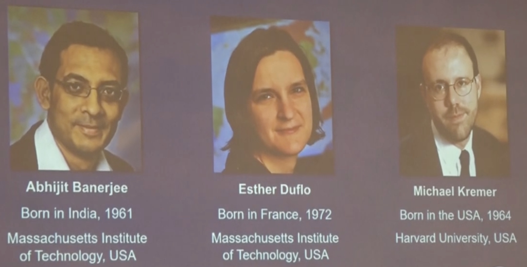

## Economia Experimental: Prêmio Nobel 2019

**Descrição**

- O trio foi premiado “*por sua abordagem *experimental* para aliviar a pobreza global*”.
- “*As descobertas das pesquisas dos premiados - e as dos pesquisadores que seguem os passos deles - melhoraram drasticamente nossa capacidade de combater a pobreza na prática”, acrescentou em comunicado a Academia Real de Ciências da Suécia*.”
- [Research to help the world’s poor](https://www.nobelprize.org/uploads/2019/10/popular-economicsciencesprize2019-2.pdf)
- [J-Pal](https://www.povertyactionlab.org)

## Causalidade

**Exemplo: Retornos da educação**

Economistas do trabalho, formuladores de políticas públicas, pais e estudantes estão todos interessados no *retorno (monetário) da educação.*

Experimento mental:

- Selecione aleatoriamente um indivíduo.
- Conceda a essa pessoa um ano adicional de educação<sup>1</sup>
- Em quanto aumentaria sua renda?

Essa variação na renda fornece o **efeito causal** da educação sobre a renda.

[^5]: Certamente não é ético aleatorizar anos de escolaridade.

## Causalidade

**Exemplo: Retornos da educação**

**P:** Poderíamos simplesmente regredir a renda em função da educação?

**R:** Mais uma vez, provavelmente não, se quisermos o verdadeiro efeito causal.

1. O nível de educação de educação de uma pessoa é determinado por vários fatores, *por exemplo*: habilidade, motivação.
2. Assim, o nível educacional é correlacionado com uma característica não observável, como habilidade, que afetam a renda
3. Além disso, a educação provavelmente reduz a experiência (tempo fora do mercado de trabalho).
4. Assim, a educação é **endógena** (viola a condição de *exogeneidade*).

O ponto (3) acima também ilustra a dificuldade de estudar os efeitos da educação mantendo *todo o restante constante*.

Muitas variáveis importantes enfrentam o mesmo desafio — gênero, raça, renda.

## Causalidade

**Exemplo: Retornos da educação**

**P:** Então, como podemos estimar os retornos da educação?

Opção 1: Realizar um **experimento**.

- Aleatoriamente atribuir níveis de educação (pode ser difícil).
- Aleatoriamente estimular a educação (pode funcionar).
- Aleatoriamente designar programas que afetem a educação (*por exemplo*, mentoria).

Opção 2: Buscar um *experimento natural* — uma política pública ou um evento acidental na sociedade que aumentou de forma arbitrária o nível de educação para um determinado grupo de pessoas.

- Pontos de corte em processos de admissão
- Sorteios de vagas e/ou restrições de capacidade

## Causalidade

**Experimentos no mundo real**

Ambos os exemplos consideram **experimentos reais** que isolam efeitos causais.

Características

- Viáveis — podemos de fato (ou potencialmente) realizar o experimento.
- Comparar indivíduos alocados aleatoriamente no grupo de tratamento com indivíduos alocados aleatoriamente no grupo de controle.
- Exigem uma “boa” aleatorização para obter a condição de *tudo o mais constante* (exogeneidade).

*Observação:* Os resultados do seu experimento são tão bons quanto a qualidade da sua aleatorização.

[figure not shown]

Figura 15: Aleatorização desfavorável.

## Causalidade

**O experimento ideal**

O **experimento ideal** seria sutilmente diferente.

Em vez de comparar unidades aleatoriamente designadas como tratamento versus controle, o experimento ideal compararia tratamento e controle **para a mesma unidade exata**.

$$\begin{align}
y_{\text{Tratamento},i} - y_{\text{Controle},i}
\end{align}$$

que escreveremos (por simplicidade) como

$$\begin{align}
y_{1,i} - y_{0,i}
\end{align}$$

Esse *experimento ideal* é claramente inviável†<sup>1</sup>, mas fornece uma notação conveniente para o estudo da causalidade (o modelo causal de Rubin / estrutura de resultados potenciais de Neyman).

[^6]: Sem (1) habilidades divinas e múltiplos universos ou (2) uma máquina do tempo.

## Causalidade

**O Experimento Ideal**

#### Dados *ideais* para 10 indivíduos

```
#>     i trt  y1i  y0i effect_i
#> 1   1   1 5.01 2.56     2.45
#> 2   2   1 8.85 2.53     6.32
#> 3   3   1 6.31 2.67     3.64
#> 4   4   1 5.97 2.79     3.18
#> 5   5   1 7.61 4.34     3.27
#> 6   6   0 7.63 4.15     3.48
#> 7   7   0 4.75 0.56     4.19
#> 8   8   0 5.77 3.52     2.25
#> 9   9   0 7.47 4.49     2.98
#> 10 10   0 7.79 1.40     6.39
```

#### Cálculo do efeito causal do tratamento do indivíduo i

$$\tau_i = y_{1,i} - y_{0,i}$$

para cada indivíduo $i$.

A média de $\tau_i$ é o efeito médio do tratamento (ATE — *Average Treatment Effect*).

$$\color{#e64173}{\overline{\tau} = 3.82}$$

## Causalidade

**O experimento ideal**

Este modelo evidencia o problema fundamental da inferência causal.
$$\begin{align}
\tau_i = \color{#e64173}{y_{1,i}} &- \color{#6A5ACD}{y_{0,i}}
\end{align}$$

**O desafio:**

Se observamos $\color{#e64173}{y_{1,i}}$, então não podemos observar $\color{#6A5ACD}{y_{0,i}}$.

Se observamos $\color{#6A5ACD}{y_{0,i}}$, então não podemos observar $\color{#e64173}{y_{1,i}}$.

## Causalidade

**O experimento ideal**

```
#>     i trt  y1i  y0i
#> 1   1   1 5.01   NA
#> 2   2   1 8.85   NA
#> 3   3   1 6.31   NA
#> 4   4   1 5.97   NA
#> 5   5   1 7.61   NA
#> 6   6   0   NA 4.15
#> 7   7   0   NA 0.56
#> 8   8   0   NA 3.52
#> 9   9   0   NA 4.49
#> 10 10   0   NA 1.40
```

Não podemos observar simultaneamente $\color{#e64173}{y_{1,i}}$ e $\color{#6A5ACD}{y_{0,i}}$.

Mas observamos:

- $\color{#e64173}{y_{1,i}}$ para $i = 1, 2, 3, 4, 5$
- $\color{#6A5ACD}{y_{0,j}}$ para $j = 6, 7, 8, 9, 10$

**Pergunta:** como podemos “preencher” os valores `NA` e estimar $\overline{\tau}$?

## Estudo Observacional

**Descrição**

- Um **estudo observacional** em é um tipo de pesquisa em que o investigador coleta dados sem intervir ou alterar as condições (variáveis) nas quais os elementos são observados.
- Este tipo de estudo registra as variáveis de interesse conforme elas ocorrem naturalmente, sem controle das condições ou tratamentos.
- Embora úteis para identificar correlações e explorar tendências, os estudos observacionais podem ser susceptíveis a viéses, uma vez que a ausência de aleatorização e controle limita a capacidade de inferir relações causais com segurança.
- Talvez a forma mais comum de estudo observacional sejam os estudos envolvendo dados em seção-cruzada e analisados por modelos de regressão linear.

## Inferência Causal: Prêmio Nobel 2021

[figure not shown]

**Descrição**

“*Os Laureados deste ano - David Card, Joshua Angrist e Guido Imbens - mostraram que [*experimentos naturais*](https://en.wikipedia.org/wiki/Natural_experiment) podem ser usados para responder a questões centrais para a sociedade, tais como os salários mínimos e a imigração afetam o mercado de trabalho. Eles também esclareceram exatamente quais conclusões sobre causa e efeito podem ser tiradas usando essa abordagem de pesquisa. Juntos, eles *revolucionaram a pesquisa empírica nas ciências econômicas**.”

- [Natural experiments help answer important questions](https://www.nobelprize.org/uploads/2021/10/popular-economicsciencesprize2021-3.pdf)

## Causalidade

**Estimando causalmente o efeito do tratamento**

Notação: Seja $D_i$ uma variável indicadora binária tal que

- $\color{#e64173}{D_i=1}$ se o indivíduo $\color{#e64173}{i}$ recebe o tratamento.
- $\color{#6A5ACD}{D_i=0}$ se o indivíduo $\color{#6A5ACD}{i}$ não recebe o tratamento (grupo de controle).

Então, reformulando o slide anterior,

- Observamos apenas $\color{#e64173}{y_{1,i}}$ quando $\color{#e64173}{D_{i}=1}$.
- Observamos apenas $\color{#6A5ACD}{y_{0,i}}$ quando $\color{#6A5ACD}{D_{i}=0}$.

**P:** Como podemos estimar $\overline{\tau}$ utilizando apenas $\left(\color{#e64173}{y_{1,i}|D_i=1}\right)$ e $\left(\color{#6A5ACD}{y_{0,i}|D_i=0}\right)$?

## Causalidade

**Estimando causalmente o efeito do tratamento**

**P:** Como podemos estimar $\overline{\tau}$ utilizando apenas $\left(\color{#e64173}{y_{1,i}\mid D_i=1}\right)$ e $\left(\color{#6A5ACD}{y_{0,i}\mid D_i=0}\right)$?

**Ideia:** E se comparássemos as médias dos grupos? *Ou seja*,

$$\begin{align}
\color{#e64173}{\mathop{Méd}\left( y_i\mid D_i = 1 \right)} - \color{#6A5ACD}{\mathop{Méd}\left( y_i\mid D_i =0 \right)}
\end{align}$$

**P:** Em que situação essa simples diferença entre as médias dos grupos fornece informação sobre o efeito causal do tratamento?

**P₂:** Será que $\color{#e64173}{\mathop{Méd}\left( y_i\mid D_i = 1 \right)} - \color{#6A5ACD}{\mathop{Méd}\left( y_i\mid D_i =0 \right)}$ é um *bom* estimador para $\overline{\tau}$?

## Causalidade

**Estimando causalmente o efeito do tratamento**

**Hipótese:** Seja $\tau_i = \tau$ para todo $i$.

Essa suposição afirma que o efeito do tratamento é igual (constante) para todos os indivíduos $i$.

**Nota:** Definimos

$$\begin{align}
\tau_i = \tau = \color{#e64173}{y_{1,i}} - \color{#6A5ACD}{y_{0,i}}
\end{align}$$

o que implica que

$$\begin{align}
\color{#e64173}{y_{1,i}} = \color{#6A5ACD}{y_{0,i}} + \tau
\end{align}$$

## Causalidade

**Estimando causalmente o efeito do tratamento**

**P₃:** Será que $\color{#e64173}{\mathop{Med}\left( y_i\mid D_i = 1 \right)} - \color{#6A5ACD}{\mathop{Med}\left( y_i\mid D_i =0 \right)}$ é um *bom* estimador para $\tau$?

Diferença entre as médias dos grupos

= $\quad \color{#ffffff}{\Bigg|} = \color{#e64173}{\mathop{Med}\left( y_i\mid D_i = 1 \right)} - \color{#6A5ACD}{\mathop{Med}\left( y_i\mid D_i =0 \right)}$

= $\quad \color{#ffffff}{\Bigg|} = \color{#e64173}{\mathop{Med}\left( y_{1,i}\mid D_i = 1 \right)} - \color{#6A5ACD}{\mathop{Med}\left( y_{0,i}\mid D_i =0 \right)}$

= $\quad \color{#ffffff}{\Bigg|} = \color{#e64173}{\mathop{Med}\left(\color{#000000}{\tau \: +} \: \color{#6A5ACD}{y_{0,i}} \color{#e64173}\mid D_i = 1 \right)} - \color{#6A5ACD}{\mathop{Med}\left( y_{0,i}\mid D_i =0 \right)}$

= $\quad \tau + \color{#e64173}{\operatorname{Med}\!\left( {\color{#6A5ACD}{y_{0,i}}} \mid D_i = 1 \right)} - \color{#6A5ACD}{\operatorname{Med}\!\left( y_{0,i} \mid D_i = 0 \right)}$

= $\quad \text{Efeito causal médio} + \color{#FFA500}{\text{Viés de seleção}}$

## Causalidade

**Estimando causalmente o efeito do tratamento**

- $\quad \text{Efeito causal médio} + \color{#FFA500}{\text{Viés de seleção}}$
- Assim, o estimador proposto — a diferença entre as médias dos grupos — nos fornece a soma de:
1. $\tau$, o efeito causal médio do tratamento que desejamos;
2. Viés de seleção: o quanto os grupos de tratamento e controle diferem (em média).
- Vamos compreender uma “solução” para o viés de seleção: **variáveis instrumentais**

# Variáveis Instrumentais

## Causalidade

**Revisão**

Vamos revisar/reforçar o conceito de causalidade.

Trabalhamos com o *modelo causal de Rubin*, no qual definimos:

- $\color{#e64173}{y_{1i}:}$ o resultado para o indivíduo $i$ caso ele tivesse recebido o tratamento
- $\color{#6A5ACD}{y_{0i}:}$ o resultado para o indivíduo $i$ caso ele não tivesse recebido o tratamento

e nos referimos aos indivíduos que não receberam o tratamento como *grupo de controle*.

*Se* fôssemos capazes de conhecer tanto $\color{#e64173}{y_{1i}}$ *quanto* $\color{#6A5ACD}{y_{0i}}$, poderíamos calcular o efeito causal do tratamento para o indivíduo $i$, *ou seja*,

$$\begin{align}
\tau_i = \color{#e64173}{y_{1i}} - \color{#6A5ACD}{y_{0i}}
\end{align}$$

## Causalidade

**Revisão**

**Problema fundamental da inferência causal:**

Não podemos conhecer simultaneamente $\color{#e64173}{y_{1i}}$ e $\color{#6A5ACD}{y_{0i}}$.

Ou observamos o indivíduo $i$ no grupo de tratamento, *ou seja*,

$$\begin{align}
\tau_i = \color{#e64173}{y_{1i}} - \color{#6A5ACD}{?}
\end{align}$$

ou observamos o indivíduo $i$ no grupo de controle, *ou seja*,

$$\begin{align}
\tau_i = \color{#e64173}{?} - \color{#6A5ACD}{y_{0i}}
\end{align}$$

mas nunca ambos ao mesmo tempo.

## Causalidade

**Revisão**

Se quisermos conhecer $\tau_i$ (ou pelo menos $\overline{\tau}$), o que podemos fazer?

**Ideia:** Estimar o efeito médio do tratamento como a diferença entre os resultados médios no grupo de tratamento e no grupo de controle, *ou seja*,

$$\begin{align}
\color{#e64173}{\mathop{Méd}\left( y_i\mid D_i = 1 \right)} - \color{#6A5ACD}{\mathop{Méd}\left( y_i\mid D_i =0 \right)}
\end{align}$$

onde $D_i=1$ se o indivíduo $i$ recebeu o tratamento, e $D_i=0$ se o indivíduo $i$ pertence ao grupo de controle.

## Causalidade

**Revisão**

**Resultado:** Mostramos que, mesmo quando o efeito do tratamento é constante  
(ou seja, $\tau_i=\tau$ para todo $i$),

$$\begin{align}
&\color{#e64173}{\mathop{Med}\!\left( y_i \mid D_i = 1 \right)}
{\color{black}{-}}
\color{#6A5ACD}{\mathop{Med}\!\left( y_i \mid D_i = 0 \right)} \\
&\quad\quad = \tau +
\underbrace{
\color{#e64173}{\mathop{Med}\!\left(
\color{#6A5ACD}{y_{0,i}}\,\color{#e64173}{\mid D_i = 1}
\right)}
{\color{black}{-}}
\color{#6A5ACD}{\mathop{Med}\!\left( y_{0,i} \mid D_i = 0 \right)}
}_{\color{#FFA500}{\text{Viés de seleção}}}
\end{align}$$

o que nos diz que a diferença entre as médias dos grupos nos fornecerá uma **estimativa viesada** para o efeito causal do tratamento **se tivermos viés de seleção**.

## Causalidade

**Revisão**

**P:** O que é esse **viés de seleção**?

**R:** **(Informal)** Temos viés de seleção quando o nosso grupo de controle não oferece uma boa comparação para o grupo de tratamento.

Especificamente, o grupo de controle não nos fornece um bom **contrafactual** para como o nosso grupo de tratamento teria se comportado caso seus membros não tivessem recebido o tratamento.

Basicamente, os grupos são diferentes.

**R:** **(Formal)** O resultado médio *não tratado* de um membro do nosso **grupo de tratamento** (que não podemos observar) difere do resultado médio *não tratado* de um membro do nosso **grupo de controle**, *ou seja*,

$$\begin{align}
\color{#e64173}{\mathop{Med}\!\left(
\color{#6A5ACD}{y_{0,i}}\,\color{#e64173}{\mid D_i = 1}
\right)}
\color{#6A5ACD}{-}
\color{#6A5ACD}{\mathop{Med}\!\left( y_{0,i} \mid D_i = 0 \right)}
\end{align}$$

## Causalidade

**Revisão**

**Problema prático:** O viés de seleção também é difícil de observar.

$$\begin{align}
\underbrace{
\color{#e64173}{\mathop{Med}\!\left(
\color{#6A5ACD}{y_{0,i}}\,\color{#e64173}{\mid D_i = 1}
\right)}
}_{\color{#e64173}{\text{Não nobservável}}}
\color{#6A5ACD}{-}
\color{#6A5ACD}{\mathop{Med}\!\left( y_{0,i} \mid D_i = 0 \right)}
\end{align}$$

(retornando ao *problema fundamental da inferência causal*)

**Problema maior:** Se houver viés de seleção, nossa estimativa para $\tau$ será viesada, impedindo-nos de compreender o efeito causal do tratamento.

Parece um pouco com o viés por omissão de variável, certo?

Nossa variável de tratamento está correlacionada com algo que torna os dois grupos diferentes.

## Causalidade

**Revisão**

**Exemplo:** Imagine que temos duas pessoas — A e B — e um único tratamento binário: faculdade. Estamos interessados no efeito da faculdade sobre os rendimentos.

Rend<sub>1,A</sub> = $60 mil  
Rend<sub>0,A</sub> = $30 mil

Rend<sub>1,B</sub> = $140 mil  
Rend<sub>0,B</sub> = $110 mil

Ambos apresentam o mesmo efeito do tratamento (retorno à faculdade):

$\quad\quad \tau_{A} = \color{#e64173}{Rend_{1,A}} - \color{#6A5ACD}{Rend_{0,A}} = \color{#e64173}{\$60 mil} - \color{#6A5ACD}{\$30 mil} = \$30 mil$

$\quad\quad \tau_{B} = \color{#e64173}{Rend_{1,B}} - \color{#6A5ACD}{Rend_{0,B}} = \color{#e64173}{\$140 mil} - \color{#6A5ACD}{\$110 mil} = \$30 mil$

Mas qualquer estimativa no mundo real apresentaria sérios problemas de seleção, já que $\color{#6A5ACD}{Rend_{0,A}} \neq \color{#6A5ACD}{Rend_{0,B}}.$

## Causalidade

**Revisão**

**Exemplo:** Imagine que temos duas pessoas — A e B — e um único tratamento binário: faculdade. Estamos interessados no efeito da faculdade sobre os rendimentos.

Rend<sub>1,A</sub> = $60 mil  
Rend<sub>0,A</sub> = $30 mil

Rend<sub>1,B</sub> = $140 mil  
Rend<sub>0,B</sub> = $110 mil

O viés de seleção…

Se B cursou faculdade ($D_{B}=1$) e A não cursou ($D_{A}=0$):

$\quad\quad\hat{\tau} = \color{#e64173}{Rend_{1,B}} - \color{#6A5ACD}{Rend_{0,A}} = \color{#e64173}{\$140 mil} - \color{#6A5ACD}{\$30 mil} = \$110 mil$

Se A cursou faculdade ($D_{A}=1$) e B não cursou ($D_{B}=0$):

$\quad\quad\hat{\tau} = \color{#e64173}{Rend_{1,A}} - \color{#6A5ACD}{Rend_{0,B}} = \color{#e64173}{\$60 mil} - \color{#6A5ACD}{\$110 mil} = -\$50 mil$

## Causalidade

**O que o exemplo com A e B mostra?**

- O exemplo ilustra o problema do viés de seleção.
- Mesmo que o efeito da faculdade seja o mesmo para ambos (30 mil), comparar diretamente quem cursou com quem não cursou pode levar a uma estimativa incorreta do efeito causal.
- **Por quê?**
- Porque quem cursa faculdade (ex: B) pode já ter, por outros motivos, um rendimento maior mesmo sem tratamento.
- Ou seja, A e B diferem em características pré-existentes não observadas (como talento, motivação, ambiente familiar).
- Se usamos $Rend_{0,A}$ como contrafactual para B, ou $Rend_{1,A}$ para estimar o tratamento em A, confundimos o **efeito da faculdade** com **diferenças entre indivíduos**.
- Isso gera **viés de seleção**: o grupo de controle não representa adequadamente o que teria acontecido com o grupo de tratamento na ausência da faculdade.

## Causalidade

**Revisão**

Temos (pelo menos) dois problemas…

1. O viés de seleção é difícil de observar, pois envolve diferenças em contrafactuais não observados — isto é, no que teria acontecido com os indivíduos do grupo de tratamento caso não tivessem sido tratados.
2. Se houver viés de seleção, nossa estimativa de $\tau$ será viesada, o que nos impede de obter o efeito causal do tratamento.

**Solução:** eliminar ou minimizar o viés de seleção.

- **Opção 1:** **Distribuir o tratamento** de modo que os grupos de tratamento e controle sejam essencialmente idênticos (experimentos).
- **Opção 2:** **Construir um grupo de controle** que *corresponda* ao grupo de tratamento

(Essa é a vida com dados observacionais).

## Variáveis Instrumentais

**Introdução**

**Variáveis Instrumentais (VI)** constituem um dos caminhos frequentemente utilizados por econometristas para estimar o efeito causal de um tratamento ou programa.

*Relembrando:* **Viés de seleção** significa que nossos grupos de tratamento e controle diferem em alguma dimensão não observada ou omitida (endogeneidade).

Usamos uma VI $z$ para obter uma medida da **parte exógena** de uma variável explicativa endógena $x$ — isto é, a variação de $x$ que é determinada por um fator externo, não correlacionado com o erro $u$.

**Variáveis instrumentais** buscam separar:

- a parte exógena de $x$, que nos fornece estimativas não viesadas;
- da parte endógena de $x$, que introduz viés em nossos resultados.

Se isolarmos apenas a variação exógena (*boa*) de $x$, poderemos evitar o viés de seleção e o viés por variável omitida, e podemos obter estimativas causais consistentes, mesmo sem aleatorização direta

## Variáveis Instrumentais

**Exemplo: Angrist (1990)**

*Exemplo:* Se quisermos estimar o efeito do status de veterano sobre os rendimentos:

$$\begin{align}
\text{Rendimentos}_i = \beta_0 + \beta_1 \text{Veterano}_i + u_i \tag{1}
\end{align}$$

Seria ótimo poder calcular $\color{#e64173}{\text{Rendimentos}_{1i}} - \color{#6A5ACD}{\text{Rendimentos}_{0i}}$, ou seja, quanto a renda individual mudaria se a pessoa fosse veterano versus não fosse.

**Problema:** só podemos observar **um desses dois cenários** para cada indivíduo. Este é o **problema fundamental da inferência causal** no modelo de Rubin.

Ser ou não veterano **não é aleatório**. Pode depender de:

- motivação, patriotismo, renda prévia, escolaridade ou acesso à informação;
- condições de saúde;

Essas características também afetam a renda e são em geral **não observáveis**. Logo, o estimador de MQO aplicado à equação (1) provavelmente será viesado devido ao viés de seleção ou de variável omitida.

## Variáveis Instrumentais

**Exemplo introdutório**

Imagine que possamos decompor o status de veterano em uma parte exógena e uma parte endógena…

$$\begin{align}
\text{Rendimentos}_i
&= \beta_0 + \beta_1 \text{Veterano}_i + u_i \tag{1} \\
&= \beta_0 + \beta_1 \left(\text{Veterano}_i^{\text{Exog.}} + \text{Veterano}_i^{\text{Endog.}}\right) + u_i \\
&= \beta_0 + \beta_1 \text{Veterano}_i^{\text{Exog.}} + \underbrace{\beta_1 \text{Veterano}_i^{\text{Endog.}} + u_i}_{w_i} \\
&= \beta_0 + \beta_1 \text{Veterano}_i^{\text{Exog.}} + w_i
\end{align}$$

Poderíamos usar essa variação exógena no status de veterano para estimar $\beta_1$ de forma consistente.

## Variáveis Instrumentais

**Exemplo introdutório**

**P:** O que significaria uma variação exógena no status de veterano?

**R$_1$:** Decisões de alistamento militar que sejam essencialmente aleatórias — ou, pelo menos, não correlacionadas com variáveis omitidas e com o termo de erro.

**R$_2$:** **Ausência de viés de seleção:**

$$\color{#e64173}{\mathop{Med}\left(\text{Rend}_{0i}\mid\text{Vet}_i = 1\right)} - \color{#6A5ACD}{\mathop{Med}\left( \text{Rend}_{0i} \mid \text{Vet}_i = 0 \right)} = 0$$

## Variáveis Instrumentais

**Instrumentos**

**P:** Como isolamos essa *variação exógena* em nossa variável explicativa?

**R:** Encontramos um instrumento (uma variável instrumental).

**P:** O que é um instrumento?

**R:** Um instrumento é uma variável que é:

1. **correlacionada** com a **variável explicativa** de interesse (relevante);
2. **não correlacionada** com o **termo de erro** (exógena).

## Variáveis Instrumentais

**Instrumentos**

**P:** O que é um instrumento?

**R:** Um instrumento é uma variável que é:

1. **correlacionada** com a **variável explicativa** de interesse (relevante);
2. **não correlacionada** com o **termo de erro** (exógena).

Assim, se quisermos um instrumento $z_i$ para o status de veterano endógeno em

$$\begin{align}
\text{Rendimentos}_i = \beta_0 + \beta_1 \text{Veterano}_i + u_i
\end{align}$$

1. Relevante: $\mathop{\text{Cov}} \left( \text{Veterano}_i,\, z_i \right) \neq 0$
2. Exógeno: $\mathop{\text{Cov}} \left( z_i,\, u_i \right) = 0$

## Sorteio da Guerra do Vietnã

**Como funcionava o sorteio da Guerra do Vietnã?**

- Entre 1969 e 1972, o governo dos EUA realizou loterias públicas anuais.
- Cada data de nascimento (1º jan a 31 dez) era sorteada e associada a um número de convocação (1–366).
- Isso gerava uma variação exógena no status de veterano, válida como instrumento.
- Ver artigo clássico de Angrist (1990)

## Variáveis Instrumentais

**Instrumentos: Relevância**

Relevância: Precisamos que o instrumento provoque uma variação (ou seja, seja correlacionado) com a nossa variável explicativa endógena.

De fato, podemos testar essa exigência usando uma regressão e um teste *t*.

**Exemplo:** Para o status de veterano, considere três instrumentos potenciais:

**1.** Número do seguro social  
(em branco para espaçamento)

Provavelmente não relevante  
não correlacionado com o serviço militar

**2.** Aptidão física  
(em branco para espaçamento)

Potencialmente relevante  
o serviço pode ser correlacionado com a aptidão física

**3.** Sorteio da Guerra do Vietnã

Relevante  
ser sorteado levava ao serviço militar

## Variáveis Instrumentais

**Instrumentos: Exogeneidade**

Exogeneidade: O instrumento deve ser independente de fatores omitidos que afetam nossa variável de resultado — isto é, deve ser tão bom quanto uma atribuição aleatória.

$z_i$ deve ser não correlacionado com o termo de erro $u_i$.  
Não testável.

**Exemplo:** Para o status de veterano, considere três instrumentos potenciais:

**1.** Número do seguro social  
(em branco para espaçamento)

Exógeno  
Independente de outros fatores relacionados ao serviço

**2.** Aptidão física  
(em branco para espaçamento)

Não exógeno  
a aptidão física se correlaciona com diversos outros fatores

**3.** Sorteio da Guerra do Vietnã

Exógeno  
o sorteio foi aleatório

## Variáveis Instrumentais

**Revisão sobre variáveis instrumentais**

Vamos recapitular…

- Nosso instrumento deve ser correlacionado com a variável endógena.
- Nosso instrumento deve ser não correlacionado com qualquer outra variável que afete o resultado.

Em outras palavras: O instrumento afeta nossa variável de resultado apenas por meio da variável endógena.

## Variáveis Instrumentais

**Retornando ao nosso exemplo**

Para o status de veterano, consideramos três instrumentos potenciais:

**1.** Número do seguro social  
(em branco para espaçamento)  
(em branco para espaçamento)

**Não relevante**  
**Exógeno**  
(em branco para espaçamento)

**2.** Aptidão física  
(em branco para espaçamento)  
(em branco para espaçamento)

**Provavelmente relevante**  
**Não exógeno**  
(em branco para espaçamento)

**3.** Sorteio da Guerra do Vietnã  
(em branco para espaçamento)  
(em branco para espaçamento)

**Relevante**  
**Exógeno**  
(em branco para espaçamento)

Assim, apenas o sorteio da Guerra do Vietnã parece ser um *instrumento válido*.

## Variáveis Instrumentais

**Questão**

Se temos um *instrumento válido* (por exemplo, o sorteio da Guerra do Vietnã),  
como podemos utilizá-lo?

## Variáveis Instrumentais

**Estimação**

*Relembrando:* queremos estimar o efeito do status de veterano sobre os rendimentos:

$$\begin{align}
\textcolor{#FFA500}{\text{Rendimentos}_i} = \beta_0 + \beta_1 \textcolor{#6A5ACD}{\text{Veterano}_i} + u_i
\end{align}$$

Vamos considerar dois efeitos relacionados:

1. O efeito do **instrumento** sobre a **variável endógena**, por exemplo:

$$\begin{align}
\textcolor{#6A5ACD}{\text{Veterano}_i} = \gamma_0 + \gamma_1 \textcolor{#e64173}{\text{Sorteio}_i} + v_i
\end{align}$$

2. O efeito do **instrumento** sobre a **variável dependente**, por exemplo:

$$\begin{align}
\textcolor{#FFA500}{\text{Rendimentos}_i} = \pi_0 + \pi_1 \textcolor{#e64173}{\text{Sorteio}_i} + w_i
\end{align}$$

## Variáveis Instrumentais

**Estimação**

*Relembrando:* queremos estimar o efeito do status de veterano sobre os rendimentos.

$$\begin{align}
\textcolor{#FFA500}{\text{Rendimentos}_i} = \beta_0 + \beta_1 \textcolor{#6A5ACD}{\text{Veterano}_i} + u_i
\end{align}$$

e sabemos que o sorteio afetou o status de veterano.

Sorteio ⟶ Status de veterano ⟶ Rendimentos

Com base em nossas suposições de independência e exogeneidade:

(Efeito do sorteio sobre rendimentos) =  
(Efeito do sorteio sobre o status de veterano) ×  
(Efeito do status de veterano sobre rendimentos)

## Variáveis Instrumentais

**Estimação**

Acabamos de escrever uma expressão para o efeito do sorteio sobre os rendimentos, ou seja:

(Efeito do sorteio sobre os rendimentos) =  
(Efeito do sorteio sobre o status de veterano) ×  
(Efeito do status de veterano sobre os rendimentos)

Mas o que queremos saber é o efeito do status de veterano sobre os rendimentos.  
Reorganize a expressão!

(Efeito do status de veterano sobre os rendimentos) =

(Efeito do sorteio sobre os rendimentos) / (Efeito do sorteio sobre o status de veterano)

Nosso instrumento estima de forma consistente ambas as partes dessa fração!

## Variáveis Instrumentais

**Estimação: Decomposição Formal**

Queremos estimar o efeito causal de $X_i$ (ex.: ser veterano) sobre $Y_i$ (ex.: rendimentos), mas $X_i$ é endógeno.

**Solução:** usar um instrumento $Z_i$ (ex.: sorteio da Guerra do Vietnã), desde que:

- $Z_i$ seja **relevante**: $\mathbb{E}[X_i \mid Z_i]$ varia com $Z_i$
- $Z_i$ seja **exógeno**: $\mathbb{E}[u_i \mid Z_i] = 0$

Aplicamos o valor esperado condicional na equação estrutural:

$$\begin{align}
Y_i &= \beta_0 + \beta_1 X_i + u_i \\\\[0.5em]
\mathbb{E}[Y_i \mid Z_i]
&= \beta_0 + \beta_1 \mathbb{E}[X_i \mid Z_i] + \mathbb{E}[u_i \mid Z_i] \\\\[0.5em]
&= \beta_0 + \beta_1 \mathbb{E}[X_i \mid Z_i] \quad \text{(por exogeneidade: } \mathbb{E}[u_i \mid Z_i] = 0\text{)}
\end{align}$$

Essa equação pode ser estimada em dois grupos ($Z_i = 1$ e $Z_i = 0$) e nos leva ao estimador de Wald:

$$\hat{\beta}_1^\text{IV} =
\frac{
\mathbb{E}[Y_i \mid Z_i = 1] - \mathbb{E}[Y_i \mid Z_i = 0]
}{
\mathbb{E}[X_i \mid Z_i = 1] - \mathbb{E}[X_i \mid Z_i = 0]
}$$

## Variáveis Instrumentais

**Estimação: Integrando tudo**

Ao estimarmos duas regressões envolvendo nosso instrumento:

1. O efeito do instrumento sobre a variável endógena, por exemplo:

$$\begin{align}
\textcolor{#6A5ACD}{\text{Veterano}_i} = \gamma_0 + \gamma_1 \textcolor{#e64173}{\text{Sorteio}_i} + v_i
\end{align}$$

2. O efeito do instrumento sobre a variável de resultado, por exemplo:

$$\begin{align}
\textcolor{#FFA500}{\text{Rendimentos}_i} = \pi_0 + \pi_1 \textcolor{#e64173}{\text{Sorteio}_i} + w_i
\end{align}$$

podemos estimar o efeito desejado:

(Efeito do status de veterano sobre os rendimentos) =

(Efeito do sorteio sobre os rendimentos) / (Efeito do sorteio sobre o status de veterano)

## Variáveis Instrumentais

**Estimação: Integrando tudo**

Ao estimarmos duas regressões envolvendo nosso instrumento:

1. O efeito do instrumento sobre a variável endógena, por exemplo:

$$\begin{align}
\textcolor{#6A5ACD}{\text{Veterano}_i} = \gamma_0 + \gamma_1 \textcolor{#e64173}{\text{Sorteio}_i} + v_i
\end{align}$$

2. O efeito do instrumento sobre a variável de resultado, por exemplo:

$$\begin{align}
\textcolor{#FFA500}{\text{Rendimentos}_i} = \pi_0 + \pi_1 \textcolor{#e64173}{\text{Sorteio}_i} + w_i
\end{align}$$

podemos estimar o efeito desejado:

(Efeito do status de veterano sobre os rendimentos) = $\dfrac{\pi_1}{\gamma_1}$

## Variáveis Instrumentais

**Estimação: Integrando tudo**

Assim, com variáveis instrumentais, estimamos $\beta_1$ usando:

$$\begin{align}
\hat{\beta}_1^\text{IV} = \dfrac{\hat{\pi}_1}{\hat{\gamma}_1}
\end{align}$$

onde $\hat{\pi}_1$ e $\hat{\gamma}_1$ vêm das duas equações que acabamos de discutir.

**P:** Podemos confiar em $\hat{\beta}_1^\text{IV}$?

**R:** Sim… **se tivermos um instrumento válido.**

$$\begin{align}
\mathop{\text{plim}}\left( \hat{\beta}_1^\text{IV} \right)
= \beta_1 + \dfrac{
\mathop{\text{Cov}}\left( \textcolor{#e64173}{\text{Instrumento}},\, u \right)
}{
\mathop{\text{Cov}}\left( \textcolor{#e64173}{\text{Instrumento}},\, \textcolor{#6A5ACD}{\text{Var. endógena}} \right)
}
\end{align}$$

que será igual a $\beta_1$ desde que nosso instrumento seja exógeno (numerador) e relevante (denominador).

## Conjunto de Dados `wage2`

**Descrição Geral**

O conjunto de dados **wage2** faz parte do pacote **wooldridge** e contém informações extraídas do artigo de Blackburn e Neumark (1992).

Os dados referem-se a **935 observações individuais** do ano de **1980** sobre variáveis relacionadas a rendimentos, educação, experiência e características demográficas de trabalhadores nos Estados Unidos.

#### Principais Variáveis

| Variável | Descrição |
| --- | --- |
| `wage` | Ganhos mensais em dólares de 1980. |
| `lwage` | Logaritmo natural do salário mensal (`log(wage)`). |
| `educ` | Anos de escolaridade do indivíduo. |
| `meduc` | Anos de escolaridade da mãe. |
| `feduc` | Anos de escolaridade do pai. |
| `exper` | Anos de experiência potencial no mercado de trabalho. |
| `tenure` | Tempo de permanência no emprego atual (em anos). |
| `hours` | Média de horas semanais trabalhadas. |
| `married` | Indicador de estado civil (1 = casado). |
| `south` | Indicador para residência na região sul dos EUA. |

- A variável `wage` **representa o salário mensal** em dólares correntes de 1980,  
  não ajustados pela inflação.

## Variáveis Instrumentais

**Examplo em R**

De volta à antiga batalha para estimar o retorno do investimento em educação.

```
#> # A tibble: 722 × 4
#>    salario educacao educacao_pai educacao_mae
#>      <int>    <int>        <int>        <int>
#>  1     769       12            8            8
#>  2     808       18           14           14
#>  3     825       14           14           14
#>  4     650       12           12           12
#>  5     562       11           11            6
#>  6     600       10            8            8
#>  7    1154       15            5           14
#>  8    1000       12           11           12
#>  9     930       18           14           13
#> 10     900       15           12           12
#> # ℹ 712 more rows
```

## Variáveis Instrumentais

**Examplo em R**

O estimador de MQO para os retornos da educação provavelmente (com certeza) será viesado…

$$\begin{align}
\color{#FFA500}{\text{Salário}_i} = \beta_0 + \beta_1 \color{#6A5ACD}{\text{Educação}}_i + u_i
\end{align}$$

Resultados (provavelmente viesado) de MQO:

| Parâmetro | Est. | E.P. | est. t | Valor-p |
| --- | --- | --- | --- | --- |
| Intercepto | 176.504 | 89.152 | 1.98 | 0.04811 |
| Educação | 58.594 | 6.439 | 9.10 | 0.00000 |

mas e se a educação da mãe fornecer um instrumento válido?

## Exemplo em R

**Exemplo em R**

Podemos verificar/testar a *relevância* da **educação da mãe** para a **educação**.

Essa regressão é conhecida como o **primeiro estágio**:

O efeito do instrumento sobre nossa variável explicativa endógena.

$$\begin{align}
\textcolor{#6A5ACD}{\text{Educação}_i} = \gamma_0 + \gamma_1 \textcolor{#e64173}{\left( \text{Educação da Mãe} \right)_i} + v_i
\end{align}$$

Resultados do primeiro estágio:

| Parâmetro | Est. | E.P. | est. t | Valor-p |
| --- | --- | --- | --- | --- |
| Intercepto | 10.487 | 0.306 | 34.32 | 0 |
| Educação da Mãe | 0.294 | 0.027 | 10.75 | 0 |

O valor-*p* sugere uma relação muito forte (isto é, uma variável altamente *relevante*).

## Variáveis Instrumentais

[figure not shown]

Figura 16: Visualizando o primeiro estágio

## Variáveis Instrumentais

[figure not shown]

Figura 17: Visualizando o primeiro estágio

## Variáveis Instrumentais

**Exogeneidade**

**P:** O que significa exogeneidade neste caso?

**R:** Precisamos de duas condições:

1. A educação da mãe (nosso instrumento) deve afetar os rendimentos apenas por meio da educação (nossa variável explicativa endógena).
2. A educação da mãe deve ser não correlacionada com outros fatores que afetam os salários (nossa variável de resultado).

Queremos ser capazes de comparar duas pessoas (*A* e *B*) cujas mães possuem níveis diferentes de educação e afirmar que as únicas diferenças entre essas pessoas (*A* e *B*) são decorrentes dos níveis educacionais de suas mães.

**P:** A *educação da mãe* parece satisfazer a condição de exogeneidade?

## Variáveis Instrumentais

**Exemplo em R**

Agora, vamos estimar a **forma reduzida**:  
O efeito do instrumento sobre nossa variável de resultado.

$$\begin{align}
\textcolor{#FFA500}{\text{Salário}_i} = \pi_0 + \pi_1 \textcolor{#e64173}{\left( \text{Educação da Mãe} \right)_i} + w_i
\end{align}$$

**Resultados da forma reduzida**:

| Parâmetro | Est. | E.P. | est. t | Valor-p |
| --- | --- | --- | --- | --- |
| Intercepto | 633.34 | 58.58 | 10.81 | 0 |
| Educação da Mãe | 31.81 | 5.24 | 6.07 | 0 |

- Como interpretamos este coeficiente estimado $\left( \hat{\pi}_1 \right)$?

## Variáveis Instrumentais

**Exemplo em R**

Então, qual é a nossa estimativa baseada em VI para o retorno da educação?

$$\begin{align}
\textcolor{#FFA500}{\text{Salário}_i} = \beta_0 + \beta_1 \textcolor{#6A5ACD}{\text{Educação}_i} + u_i
\end{align}$$

Sabemos que a estimativa de VI para $\beta_1$ é:

$$\begin{align}
\hat{\beta}_1^\text{IV} = \dfrac{\textcolor{#20B2AA}{\hat{\pi}_1}}{\textcolor{#314f4f}{\hat{\gamma}_1}}
\end{align}$$

1. Na equação de forma reduzida, estimamos $\textcolor{#20B2AA}{\hat{\pi}_1 \approx 31.81}$.
2. Na equação do primeiro estágio, estimamos $\textcolor{#314f4f}{\hat{\gamma}_1 \approx 0.294}$.

$$\begin{align}
\implies \hat{\beta}_1^\text{IV}
= \dfrac{\textcolor{#20B2AA}{\hat{\pi}_1}}{\textcolor{#314f4f}{\hat{\gamma}_1}}
= \dfrac{\textcolor{#20B2AA}{31.81}}{\textcolor{#314f4f}{0.294}}
\approx 108.2
\end{align}$$

## Variáveis Instrumentais

**Exemplo em R**

**Alternativa:** Use a função `iv_robust()` do pacote `estimatr`.

Essa função `iv_robust` funciona de forma muito semelhante à nossa conhecida `lm`:

`iv_robust(y ~ x | z, data = dataset)`

- `formula` Especifique a regressão, seguida por `|` e pelo seu instrumento (`z`).
- `data` Você ainda precisa fornecer um conjunto de dados.

*Observação:* Como o próprio nome sugere, `iv_robust` calcula erros-padrão robustos à heterocedasticidade por padrão.

## Variáveis Instrumentais

**Exemplo em R**

Na prática…

```r
# Estima a regressão de VI
iv_est <- iv_robust(salario ~ educacao | educacao_mae, data = wage_df)
```

| Parâmetro | Est. | E.P. | est. t | Valor-p |
| --- | --- | --- | --- | --- |
| Intercepto | -501.474 | 226.476 | -2.21 | 0.02712 |
| Educação | 108.214 | 16.810 | 6.44 | 0.00000 |

## Variáveis Instrumentais

**Mais**

Agora sabemos como “fazer” variáveis instrumentais *quando temos uma variável endógena e uma variável exógena.*

1. Estime a forma reduzida (regressione a variável de resultado sobre o instrumento).
2. Estime o primeiro estágio (regressione a variável explicativa sobre o instrumento).
3. Calcule a estimativa de VI usando os coeficientes estimados em (1) e (2).

Nosso mágico instrumento isola a variação exógena em nossa variável endógena.

**P:** E se quisermos mais? (*Por exemplo*, mais instrumentos ou variáveis endógenas)

**R:** Estendemos o método de VI para o método dos mínimos quadrados em dois estágios (2SLS).

# Minímos Quadrados em Dois Estágios

## Mínimos Quadrados em Dois Estágios

**Introdução**

A intuição e os conceitos das VI se estendem naturalmente para o método dos mínimos quadrados em dois estágios (2SLS).

**Além disso:** O *primeiro estágio* que discutimos anteriormente é, na verdade, o *primeiro* dos *dois estágios* no método 2SLS.

$$\begin{align}
{\color{#c5c5c5}{\text{Modelo endógeno}}}& &\textcolor{#FFA500}{\text{Resultado}_i} &= \beta_0 + \beta_1 \textcolor{#6A5ACD}{\left( \text{Var. endógena} \right)_i} + u_i\\[0.5em]
{\text{Primeiro estágio}}& &\textcolor{#6A5ACD}{\left( \text{Var. endógena} \right)_i} &= \pi_0 + \pi_1 \textcolor{#e64173}{\text{Instrumento}_i} + v_i\\[0.25em]
{\text{Segundo estágio}}& &\textcolor{#FFA500}{\text{Resultado}_i} &= \delta_0 + \delta_1 \textcolor{#6A5ACD}{\widehat{\left( \text{Var. endógena} \right)}_i} + \varepsilon_i\\[0.5em]
{\color{#c5c5c5}{\text{Forma reduzida}}}& &\textcolor{#FFA500}{\text{Resultado}_i} &= \pi_0 + \pi_1 \textcolor{#e64173}{\text{Instrumento}_i} + w_i\\[0.25em]
\end{align}$$

onde $\textcolor{#6A5ACD}{\widehat{\left( \text{Var. endógena} \right)}_i}$ representa os valores previstos (*valores ajustados*) obtidos a partir da regressão do primeiro estágio.

## Mínimos Quadrados em Dois Estágios

**Introdução**

- O método dos mínimos quadrados em dois estágios (2SLS) é bastante flexível — podemos incluir outras variáveis de controle, variáveis endógenas adicionais *e* utilizar múltiplos instrumentos.
- **Mas** não se deixe distrair por toda essa flexibilidade sofisticada.
- Ainda precisamos de instrumentos **válidos**.

## Mínimos Quadrados em Dois Estágios

**Em R**

Voltando ao nosso exemplo de *retornos da educação*:

$$\begin{align}
\textcolor{#FFA500}{\text{Salário}_i} = \beta_0 + \beta_1 \textcolor{#6A5ACD}{\text{Educação}_i} + u_i
\end{align}$$

Imagine que a educação da mãe *e* a educação do pai sejam ambas instrumentos válidos.

Então, a **regressão do primeiro estágio** é:

$$\begin{align}
\textcolor{#6A5ACD}{\text{Educação}_i} = \gamma_0 + \gamma_1 \textcolor{#e64173}{\left( \text{Educação da Mãe} \right)_i} + \gamma_2 \textcolor{#e64173}{\left( \text{Educação do Pai} \right)_i} + v_i
\end{align}$$

a qual podemos estimar por MQO.

**P:** Por quê?

## Mínimos Quadrados em Dois Estágios

```r
# regressao - primeiro estágio
stage1 <- lm(educacao ~ educacao_mae + educacao_pai, wage_df)
```

**Resultados do primeiro estágio:**

| Parâmetro | Est. | E.P. | est. t | Valor-p |
| --- | --- | --- | --- | --- |
| Intercepto | 9.845 | 0.305 | 32.31 | 0 |
| Educação da Mãe | 0.149 | 0.032 | 4.62 | 0 |
| Educação do Pai | 0.216 | 0.028 | 7.84 | 0 |

**Relevancia**

- Nossos instrumentos parecem ser *relevantes*.
- Formalmente, deveríamos testá-los em conjunto (por exemplo, teste F).

## Mínimos Quadrados em Dois Estágios

**Em R**

Usando nossa estimativa do primeiro estágio, obtemos a *variável endógena ajustada* (valores previstos):

$$\begin{align}
\textcolor{#6A5ACD}{\widehat{\text{Educação}}_i}
= \widehat{\gamma}_0
+ \widehat{\gamma}_1 \textcolor{#e64173}{\left( \text{Educação da Mãe} \right)_i}
+ \widehat{\gamma}_2 \textcolor{#e64173}{\left( \text{Educação do Pai} \right)_i}
\end{align}$$

```r
# adiciona os valores previstos do primeiro estágio
wage_df$educacao_hat <- stage1$fitted.values
```

Agora usamos o MQO (novamente) para estimar a **regressão do segundo estágio**:

$$\begin{align}
\textcolor{#FFA500}{\text{Salario}}_i = \delta_0 + \delta_1 \, \widehat{\textcolor{#6A5ACD}{\text{Educacao}}}_i + \varepsilon_i
\end{align}$$

## Mínimos Quadrados em Dois Estágios

**Em R**

$$\begin{align}
\textcolor{#FFA500}{\text{Salario}}_i = \delta_0 + \delta_1 \, \widehat{\textcolor{#6A5ACD}{\text{Educacao}}}_i + \varepsilon_i
\end{align}$$

```r
# regressao - segundo estágio
stage2 <- lm(salario ~ educacao_hat, wage_df)
```

| Parâmetro | Est. | E.P. | est. t | Valor-p |
| --- | --- | --- | --- | --- |
| Intercepto | -454.683 | 198.149 | -2.29 | 0.02204 |
| Educação Prevista | 104.789 | 14.462 | 7.25 | 0.00000 |

Mínimos Quadrados Ordinários (MQO)

| Parâmetro | Est. | E.P. | est. t | Valor-p |
| --- | --- | --- | --- | --- |
| Intercepto | 176.504 | 89.152 | 1.98 | 0.04811 |
| Educação | 58.594 | 6.439 | 9.10 | 0.00000 |

Variáveis Instrumentais (VI)

| Parâmetro | Est. | E.P. | est. t | Valor-p |
| --- | --- | --- | --- | --- |
| Intercepto | -501.474 | 226.476 | -2.21 | 0.02712 |
| Educação | 108.214 | 16.810 | 6.44 | 0.00000 |

Mínimos Quadrados em Dois Estágios (2SLS) com dois instrumentos

| Parâmetro | Est. | E.P. | est. t | Valor-p |
| --- | --- | --- | --- | --- |
| Intercepto | -454.683 | 198.149 | -2.29 | 0.02204 |
| Educação | 104.789 | 14.462 | 7.25 | 0.00000 |

## Mínimos Quadrados em Dois Estágios

**Em R**

Como você provavelmente imaginou, o `R` executa automaticamente os dois estágios para você.

`iv_robust(y ~ x1 + x2 + ⋯ | z1 + z2 + ⋯, data)`

No nosso caso, temos:

- uma variável explicativa (`x`) (educação)
- dois instrumentos (`z`) (educação dos pais)

```r
iv_robust(salario ~ educacao | educacao_mae + educacao_pai,
          data = wage_df)
```

| Parâmetro | Est. | E.P. | est. t | Valor-p |
| --- | --- | --- | --- | --- |
| Intercepto | -454.683 | 199.946 | -2.27 | 0.02326 |
| Educação prevista | 104.789 | 14.852 | 7.06 | 0.00000 |

## Testes de Especificação

**Por que realizar testes de especificação?**

Os testes de diagnóstico verificam se o modelo IV fornece **estimativas causais consistentes**.

Para isso, três condições principais devem ser avaliadas:

1. **Relevância dos instrumentos** – os instrumentos explicam a variável endógena.
2. **Endogeneidade** – a variável instrumentada é de fato endógena.
3. **Validade dos instrumentos** – os instrumentos não afetam diretamente a variável dependente.

## Testes de Especificação

**Teste 1 — Instrumentos Fracos**

**Objetivo**

Verificar se os instrumentos possuem **poder explicativo suficiente** sobre a(s) variável(is) endógena(s), isto é, se estão fortemente correlacionados com as variáveis que pretendem instrumentar.

**Estatística de teste**

A função `iv_robust()` reporta a estatística F do primeira estágio, calculada para cada variável endógena instrumentada.

Formalmente, o teste baseia-se na regressão de primeira etapa:

$$X_{endog} = Z\pi + W\gamma + v,$$

onde:

- $X_{endog}$ representa as variáveis endógenas,
- $Z$ são os instrumentos,
- $W$ são as variáveis exógenas incluídas no modelo estrutural.

A estatística do teste é o **F** da hipótese conjunta:

$$H_0: \pi_1 = \pi_2 = \dots = \pi_k = 0,$$

$$H_A: \text{pelo menos um } \pi_j \neq 0.$$

Ou seja, sob $H_0$, os instrumentos não explicam as variáveis endógenas.

**Hipóteses**

- $H_0: \text{Cov}(Z, X_{endog}) = 0$ -> instrumentos são fracos.
- $H_A: \text{Cov}(Z, X_{endog}) \neq 0$ -> instrumentos são relevantes

**Regra de decisão e interpretação**

- Se $F < 10$: há evidência de **instrumentos fracos** → problema de identificação.
- Se $F \geq 10$: instrumentos considerados **fortes** (critério de Staiger e Stock, 1997).
- Valores muito baixos de $F$ implicam que o 2SLS pode gerar viés semelhante ao MQO.

Um valor de $F$ elevado e valor-p pequeno (p < 0.05) indica que os instrumentos têm forte correlação parcial com a variável endógena (identificação confiável do modelo IV).

## Testes de Especificação

**Teste 2 — Endogeneidade (Wu–Hausman)**

**Objetivo:**

Verificar se a variável instrumentada é **endógena**. Se for, o estimador MQO (OLS) é inconsistente e o uso de **IV/2SLS** é necessário.

**Estatística de teste:**

A função `iv_robust()` executa o teste de regressão de Hausman (1978) com erros robustos.

1. Primeira etapa:
   $$X = Z\pi + W\gamma + v$$
2. Segunda etapa (teste de endogeneidade):
   $$y = \beta X + W\delta + \rho\,\widehat{v} + \varepsilon$$

O teste baseia-se na hipótese formal:
$$H_0: \rho = 0 \quad \Longleftrightarrow \quad \operatorname{Cov}(X_{\text{endog}}, u) = 0$$

**Hipóteses:**

- $H_0$: a variável instrumentada é **exógena** (OLS é consistente).
- $H_A$: a variável é **endógena** (OLS é inconsistente; IV é necessário).

**Regra de decisão e interpretação:**

- **$p < 0{,}05$** → rejeita $H_0$: há **endogeneidade** → usar IV/2SLS.
- **$p \geq 0{,}05$** → não rejeita $H_0$: sem evidência de endogeneidade → OLS é consistente.
- O teste verifica se o resíduo da primeira etapa explica $y$ além de $X$ e $W$.
- Muitos instrumentos ou instrumentos fracos podem afetar tamanho/poder do teste.
- Deve ser interpretado junto ao teste de instrumentos fracos e ao de sobreidentificação.

## Testes de Especificação

**Teste 3 — Sobreidentificação (Sargan / Wooldridge)**

**Objetivo:**

Avaliar se os instrumentos são **exógenos**, ou seja, não correlacionados com o erro estrutural.

**Estatística de teste:**

A função `iv_robust()` implementa o teste escore robusto de Wooldridge (1995), que coincide com o teste de Sargan (1958).

Considere o modelo estrutural:

$$y = X\beta + u,$$

onde $X = [X_e, W]$ contém regressores **endógenos** ($X_e$) e **exógenos** ($W$). Sejam $Z = [Z_1, \dots, Z_L]$ os **instrumentos** utilizados para $X_e$.

Para que os instrumentos sejam válidos, devem satisfazer a **condição de ortogonalidade**:

$$\mathbb{E}[Z'u] = 0.$$

Essa condição expressa que os instrumentos **não estão correlacionados com o erro estrutural**, a qual, como sabemos, é uma exigência fundamental para a **consistência do estimador IV**. O teste de sobreidentificação verifica se essas restrições são satisfeitas empiricamente.

**Hipóteses**

$$H_0:\ \mathbb{E}[Z'u] = 0 \quad\Longleftrightarrow\quad \text{instrumentos válidos (exógenos)}$$

Sob $H_0$, o resíduo IV $\widehat{u}$ não deve estar correlacionado com os instrumentos $Z$. A estatística do teste é:

$$J_{\text{rob}} = n\,\widehat{u}'Z(Z'Z)^{-1}Z'\widehat{u},$$

que segue assintoticamente uma distribuição $\chi^2(q)$, onde $q = L - m$ é o número de restrições de sobreidentificação (diferença entre o número de instrumentos e de variáveis endógenas).

**Regra de decisão e interpretação:**

- **$p < 0{,}05$** → rejeita $H_0$: evidência de **instrumentos inválidos**.
- **$p \geq 0{,}05$** → não rejeita $H_0$: **sem evidência** contra a validade dos instrumentos.
- Intuitivamente, o teste verifica se os instrumentos estão **correlacionados com os resíduos da regressão IV**.
- Se houver correlação significativa, pelo menos um instrumento é **inválido**.

## Testes de Especificação

**Síntese dos diagnósticos**

| Teste | Hipótese nula | Indica problema quando | Interpretação típica / Resultado esperado |
| --- | --- | --- | --- |
| **Weak instruments** | Instrumentos são fracos | F < 10 | F $\geq$ 10 -> instrumentos fortes |
| **Wu–Hausman** | Variável instrumentada é exógena | p < 0.05 | Rejeitar H₀ -> confirma endogeneidade -> IV é necessário |
| **Overidentifying** | Instrumentos são válidos | p < 0.05 | p $\geq$ 0.05 -> instrumentos válidos (exógenos) |

## Exemplo em R

```r
modelo_final <- iv_robust(salario ~ educacao | educacao_mae + educacao_pai,
                diagnostics = TRUE,
                data = wage_df)

summary(modelo_final)
```

```
#>
#> Call:
#> iv_robust(formula = salario ~ educacao | educacao_mae + educacao_pai,
#>     data = wage_df, diagnostics = TRUE)
#>
#> Standard error type:  HC2
#>
#> Coefficients:
#>             Estimate Std. Error t value  Pr(>|t|) CI Lower CI Upper  DF
#> (Intercept)   -454.7     199.95  -2.274 2.326e-02  -847.23   -62.14 720
#> educacao       104.8      14.85   7.055 4.051e-12    75.63   133.95 720
#>
#> Multiple R-squared:  0.03903 ,   Adjusted R-squared:  0.0377
#> F-statistic: 49.78 on 1 and 720 DF,  p-value: 4.051e-12
#>
#> Diagnostics:
#>                  numdf dendf   value  p.value
#> Weak instruments     2   719 107.851  < 2e-16 ***
#> Wu-Hausman           1   719  14.689 0.000138 ***
#> Overidentifying      1    NA   0.143 0.705683
#> ---
#> Signif. codes:  0 '***' 0.001 '**' 0.01 '*' 0.05 '.' 0.1 ' ' 1
```

## Testes de Especificação

**Resumo**

Um modelo IV é considerado **válido para inferência causal** quando:

1. Os instrumentos são **relevantes** (teste de instrumentos fracos aprovado).
2. A variável instrumentada é **endógena** (teste de Wu–Hausman rejeita H₀).
3. Os instrumentos são **exógenos** (teste de sobreidentificação não rejeita H₀).

Quando essas três condições são satisfeitas, o modelo estimado com `iv_robust` fornece **estimativas causais consistentes** do efeito da variável endógena sobre o resultado.

## Mínimos Quadrados em Dois Estágios

**Tem mais!**

Como o método 2SLS isola a variação exógena em uma variável endógena, ele pode ser aplicado em outros contextos nos quais há viés decorrente de relações *endógenas*.

Aplicações comuns

- **Inferência causal geral** em dados observacionais (como já vimos).
- **Erro de mensuração:** Regressar uma $x_1$ ruidosa contra uma $x_2$ igualmente ruidosa para capturar o sinal verdadeiro.
- **Relações simultâneas** (*por exemplo*, $p$ e $q$ de oferta e demanda).

Entretanto, em qualquer aplicação de 2SLS/VI, é essencial respeitar os requisitos de  
instrumentos válidos — **exogeneidade** e **relevância**.

## Inferência Causal

**Outros Métodos**

Quando não podemos executar experimentos, podemos usar outros métodos que tentam recuperar a **variação exógena** no tratamento para estimar efeitos causais.

- **2. Diferença em Diferenças (DiD)**
- **3. Modelos com Efeitos Fixos**
- **4. Propensity Score Matching (PSM)**
- **5. Regressão com Descontinuidade (RDD)**
- Entre outros.

A escolha depende da qualidade dos dados e das hipóteses exigidas por cada método.

## Referências

ANGRIST, J. D. [Lifetime Earnings and the Vietnam Era Draft Lottery: Evidence from Social Security Administrative Records](https://www.jstor.org/stable/2006679). **American Economic Review**, v. 80, n. 3, p. 313–336, 1990.

BLACKBURN, M. L.; NEUMARK, D. [Unobserved Ability, Efficiency Wages, and Interindustry Wage Differentials](https://doi.org/10.2307/2118394). **The Quarterly Journal of Economics**, v. 107, n. 4, p. 1421–1436, nov. 1992.

BROOKS, C. **Introductory Econometrics For Finance**. 4th. ed. [s.l.] Cambridge University Press, 2019.

HAUSMAN, J. A. [Specification Tests in Econometrics](https://doi.org/10.2307/1913827). **Econometrica**, v. 46, n. 6, p. 1251–1271, 1978.

SARGAN, J. D. [The Estimation of Economic Relationships Using Instrumental Variables](https://doi.org/10.2307/1907619). **Econometrica**, v. 26, n. 3, p. 393–415, 1958.

WOOLDRIDGE, J. M. Score Diagnostics for Linear Models Estimated by Two Stage Least Squares. **In Advances in Econometrics**, v. 14, p. 66–87, 1995.

___. **Econometric Analysis of Cross Section and Panel Data**. 2nd. ed. Cambridge, MA: MIT Press, 2010.

___. **Introdução à Econometria: Uma Abordagem Moderna**. Traducao Flávio E. F. Marques. 5. ed. São Paulo, Brasil: Cengage Learning, 2016.